# Notebook 4 of 5: *Statistical Analysis*

## Dependencies

Location of files and macros

```sas
libname files "/mnt/hgfs/myfolders";
libname macros "/mnt/hgfs/myfolders/macros";
```

```
11   ods listing close;ods html5 file=stdout options(bitmap_mode='inline') device=png; ods graphics on / outputfmt=png;
NOTE: Writing HTML5 Body file: STDOUT
12
13   libname files "/mnt/hgfs/myfolders";
NOTE: Libref FILES was successfully assigned as follows:
      Engine:        V9
      Physical Name: /mnt/hgfs/myfolders
14   libname macros "/mnt/hgfs/myfolders/macros";
NOTE: Libref MACROS was successfully assigned as follows:
      Engine:        V9
      Physical Name: /mnt/hgfs/myfolders/macros
15   ods html5 close;ods listing;

16
```

The following macro finds a mean value (%positive cells) for the entire pancreas vs. head, body, and tail. This is needed for ESM figure 1 & 3, supp table 2, and figure 1.

```sas
%macro mean (A,B);

/*find a mean value (%positive cells) for the entire pancreas vs. head, body, and tail*/

PROC means data=&A nway noprint;
     class case hospbin age_group oppc_ageR;
     var &B;
     output out=&A%quote(_mean) (drop=_type_ _freq_) mean=mean_pancreas;
run;

%mend mean;
```

```
18   ods listing close;ods html5 file=stdout options(bitmap_mode='inline') device=png; ods graphics on / outputfmt=png;
NOTE: Writing HTML5 Body file: STDOUT
19
20   %macro mean (A,B);
21
22   /*find a mean value (%positive cells) for the entire pancreas vs. head, body, and tail*/
23
24   PROC means data=&A nway noprint;
25        class case hospbin age_group oppc_ageR;
26        var &B;
27        output out=&A%quote(_mean) (drop=_type_ _freq_) mean=mean_pancreas;
28   run;
29
30   %mend mean;
31   ods html5 close;ods listing;

32
```

## Data Readiness

Import and transform dataset files

### CD45 dataset

```sas
DATA cd45;
     set files.cd45;
     if case=6222 or case=6092 or case=6107 then delete; *excluding pilot data from analysis;
run;

PROC sort data = cd45;
     by case match_group hospbin age_group;
run;

PROC transpose data = cd45 out = cd45_no_insulin (rename =( a = Head b = Body c = Tail));
     by case match_group hospbin age_group;
     id sample_type2;
     var percent_cd45;
run;
```

```
1141  ods listing close;ods html5 file=stdout options(bitmap_mode='inline') device=png; ods graphics on / outputfmt=png;
NOTE: Writing HTML5 Body file: STDOUT
1142
1143  DATA cd45;
1144       set files.cd45;
1145       if case=6222 or case=6092 or case=6107 then delete; *excluding pilot data from analysis;
1146  run;
NOTE: There were 126 observations read from the data set FILES.CD45.
NOTE: The data set WORK.CD45 has 117 observations and 20 variables.
NOTE: DATA statement used (Total process time):
      real time           0.07 seconds
      cpu time            0.00 seconds

1147
1148  PROC sort data = cd45;
1149       by case match_group hospbin age_group;
1150  run;
NOTE: There were 117 observations read from the data set WORK.CD45.
NOTE: The data set WORK.CD45 has 117 observations and 20 variables.
NOTE: PROCEDURE SORT used (Total process time):
      real time           0.00 seconds
      cpu time            0.01 seconds

1151
1152  PROC transpose data = cd45 out = cd45_no_insulin (rename =( a = Head b = Body c = Tail));
1153       by case match_group hospbin age_group;
1154       id sample_type2;
1155       var percent_cd45;
1156  run;
NOTE: There were 117 observations read from the data set WORK.CD45.
NOTE: The data set WORK.CD45_NO_INSULIN has 39 observations and 9 variables.
NOTE: PROCEDURE TRANSPOSE used (Total process time):
      real time           0.01 seconds
      cpu time            0.00 seconds

1157  ods html5 close;ods listing;

1158
```

```sas
PROC export data=cd45
     outfile="cd45.csv"
     dbms=csv
     replace;
run;
```

```
1160  ods listing close;ods html5 file=stdout options(bitmap_mode='inline') device=png; ods graphics on / outputfmt=png;
NOTE: Writing HTML5 Body file: STDOUT
1161
1162  PROC export data=cd45
1163       outfile="cd45.csv"
1164       dbms=csv
1165       replace;
1166  run;
1167   /**********************************************************************
1168   *   PRODUCT:   SAS
1169   *   VERSION:   9.4
1170   *   CREATOR:   External File Interface
1171   *   DATE:      11SEP17
1172   *   DESC:      Generated SAS Datastep Code
1173   *   TEMPLATE SOURCE:  (None Specified.)
```

[output cut: 122 more lines]

### CD68 dataset

```sas
DATA cd68;
     set files.cd68;
     if case=6222 or case=6092 or case=6107 then delete; *excluding pilot data from analysis;
run;

PROC sort data = cd68;
     by case match_group hospbin age_group;
run;

PROC transpose data = cd68 out = cd68_no_insulin (rename=( a=Head b=Body c=Tail));
     by case match_group hospbin age_group;
     id sample_type2;
     var percent_CD68;
run;
```

```
53   ods listing close;ods html5 file=stdout options(bitmap_mode='inline') device=png; ods graphics on / outputfmt=png;
NOTE: Writing HTML5 Body file: STDOUT
54
55   DATA cd68;
56        set files.cd68;
57        if case=6222 or case=6092 or case=6107 then delete; *excluding pilot data from analysis;
58   run;
NOTE: There were 126 observations read from the data set FILES.CD68.
NOTE: The data set WORK.CD68 has 117 observations and 23 variables.
NOTE: DATA statement used (Total process time):
      real time           0.03 seconds
      cpu time            0.00 seconds

59
60   PROC sort data = cd68;
61        by case match_group hospbin age_group;
62   run;
NOTE: There were 117 observations read from the data set WORK.CD68.
NOTE: The data set WORK.CD68 has 117 observations and 23 variables.
NOTE: PROCEDURE SORT used (Total process time):
      real time           0.00 seconds
      cpu time            0.00 seconds

63
64   PROC transpose data = cd68 out = cd68_no_insulin (rename=( a=Head b=Body c=Tail));
65        by case match_group hospbin age_group;
66        id sample_type2;
67        var percent_CD68;
68   run;
NOTE: There were 117 observations read from the data set WORK.CD68.
NOTE: The data set WORK.CD68_NO_INSULIN has 39 observations and 9 variables.
NOTE: PROCEDURE TRANSPOSE used (Total process time):
      real time           0.00 seconds
      cpu time            0.00 seconds

69   ods html5 close;ods listing;

70
```

### Insulin dataset

```sas
DATA insulin;
     set files.insulin;
     if case=6222 or case=6092 or case=6107 then delete; *excluding pilot data from analysis;
run;

PROC sort data = insulin;
     by case match_group hospbin age_group;
run;

PROC transpose data = insulin out = insulin1 (rename =( a = Head b = Body c = Tail));
     by case match_group hospbin age_group;
     id sample_type2;
     var percent_insulin;
run;

proc PRINT data=insulin;
run;
```

The SAS System

| Obs | Case | sample_type2 | hospbin | match_group | oppc_ageR | age_group | percent_insulin |
| --- | --- | --- | --- | --- | --- | --- | --- |
| 1 | 6003 | A | 3 | 6 | 23 | 3 | 1.8283 |
| 2 | 6003 | B | 3 | 6 | 23 | 3 | 2.5740066667 |
| 3 | 6003 | C | 3 | 6 | 23 | 3 | 2.4044566667 |
| 4 | 6005 | A | 9 | 1 | 5 | 1 | 2.80085 |
| 5 | 6005 | B | 9 | 1 | 5 | 1 | 2.0971 |
| 6 | 6005 | C | 9 | 1 | 5 | 1 | 2.1478833333 |
| 7 | 6007 | A | 9 | 3 | 9 | 1 | 1.9701133333 |
| 8 | 6007 | B | 9 | 3 | 9 | 1 | 1.6219533333 |
| 9 | 6007 | C | 9 | 3 | 9 | 1 | 1.6327533333 |
| 10 | 6008 | A | 9 | 7 | 50 | 3 | 0.7234663333 |
| 11 | 6008 | B | 9 | 7 | 50 | 3 | 0.505701 |
| 12 | 6008 | C | 9 | 7 | 50 | 3 | 1.032517 |
| 13 | 6011 | A | 9 | 5 | 46 | 3 | 1.0369433333 |
| 14 | 6011 | B | 9 | 5 | 46 | 3 | 1.11986 |
| 15 | 6011 | C | 9 | 5 | 46 | 3 | 3.86339 |
| 16 | 6019 | A | 9 | 9 | 42 | 3 | 1.0779206667 |
| 17 | 6019 | B | 9 | 9 | 42 | 3 | 2.26666 |
| 18 | 6019 | C | 9 | 9 | 42 | 3 | 1.3961166667 |
| 19 | 6047 | A | 6 | 10 | 7.8 | 1 | 1.7823366667 |
| 20 | 6047 | B | 6 | 10 | 7.8 | 1 | 1.0935966667 |
| 21 | 6047 | C | 6 | 10 | 7.8 | 1 | 2.1224433333 |
| 22 | 6048 | A | 3 | 11 | 30 | 3 | 0.917634 |
| 23 | 6048 | B | 3 | 11 | 30 | 3 | 1.5497353333 |
| 24 | 6048 | C | 3 | 11 | 30 | 3 | 1.6243343333 |
| 25 | 6057 | A | 9 | 10 | 22 | 3 | 2.2846133333 |
| 26 | 6057 | B | 9 | 10 | 22 | 3 | 2.07547 |
| 27 | 6057 | C | 9 | 10 | 22 | 3 | 2.8383833333 |
| 28 | 6060 | A | 9 | 6 | 24 | 3 | 1.005877 |
| 29 | 6060 | B | 9 | 6 | 24 | 3 | 1.2035643333 |
| 30 | 6060 | C | 9 | 6 | 24 | 3 | 2.1855966667 |

[output cut: 87 more lines]

Need to export data for ESM Figure 2 generation

```sas
PROC export data=insulin
     outfile="insulin.csv"
     dbms=csv
     replace;
run;
```

[output not shown]

[output cut: 34 more lines]

```
NOTE: DATA statement used (Total process time):
      real time           0.04 seconds
      cpu time            0.00 seconds

117 records created in insulin.csv from INSULIN.


NOTE: "insulin.csv" file was successfully created.
NOTE: PROCEDURE EXPORT used (Total process time):
      real time           0.37 seconds
      cpu time            0.06 seconds

153  ods html5 close;ods listing;

154
```

### Ki67 dataset

```sas
DATA ki67;
     set files.ki67;
     if case=6222 or case=6092 or case=6107 then delete; *excluding pilot data from analysis;
run;

PROC sort data = ki67;
     by case match_group hospbin age_group;
run;

PROC transpose data = ki67 out = ki67_no_insulin (rename = (a = Head b = Body c = Tail));
     by case match_group hospbin age_group;
     id sample_type2;
     var percent_ki67;
run;

PROC transpose data = ki67 out = ki67_dual (rename = (a = Head b = Body c = Tail));
     by case match_group hospbin age_group;
     id sample_type2;
     var percent_dual;
run;
```

```
156  ods listing close;ods html5 file=stdout options(bitmap_mode='inline') device=png; ods graphics on / outputfmt=png;
NOTE: Writing HTML5 Body file: STDOUT
157
158  DATA ki67;
159       set files.ki67;
160       if case=6222 or case=6092 or case=6107 then delete; *excluding pilot data from analysis;
161  run;
NOTE: There were 126 observations read from the data set FILES.KI67.
NOTE: The data set WORK.KI67 has 117 observations and 22 variables.
NOTE: DATA statement used (Total process time):
      real time           0.03 seconds
      cpu time            0.00 seconds

162
163  PROC sort data = ki67;
164       by case match_group hospbin age_group;
165  run;
NOTE: There were 117 observations read from the data set WORK.KI67.
NOTE: The data set WORK.KI67 has 117 observations and 22 variables.
NOTE: PROCEDURE SORT used (Total process time):
      real time           0.00 seconds
      cpu time            0.00 seconds

166
167  PROC transpose data = ki67 out = ki67_no_insulin (rename = (a = Head b = Body c = Tail));
168       by case match_group hospbin age_group;
169       id sample_type2;
170       var percent_ki67;
171  run;
NOTE: There were 117 observations read from the data set WORK.KI67.
NOTE: The data set WORK.KI67_NO_INSULIN has 39 observations and 9 variables.
NOTE: PROCEDURE TRANSPOSE used (Total process time):
      real time           0.00 seconds
      cpu time            0.01 seconds

172
173  PROC transpose data = ki67 out = ki67_dual (rename = (a = Head b = Body c = Tail));
174       by case match_group hospbin age_group;
175       id sample_type2;
176       var percent_dual;
177  run;
NOTE: There were 117 observations read from the data set WORK.KI67.
NOTE: The data set WORK.KI67_DUAL has 39 observations and 9 variables.
NOTE: PROCEDURE TRANSPOSE used (Total process time):
      real time           0.00 seconds
      cpu time            0.00 seconds

178  ods html5 close;ods listing;

179
```

Need to export data for ESM Figure 3 generation

```sas
PROC export data=ki67
     outfile="ki67.csv"
     dbms=csv

replace;
run;
```

```
181  ods listing close;ods html5 file=stdout options(bitmap_mode='inline') device=png; ods graphics on / outputfmt=png;
NOTE: Writing HTML5 Body file: STDOUT
182
183  PROC export data=ki67
184       outfile="ki67.csv"
185       dbms=csv
186       replace;
187  run;
188   /**********************************************************************
189   *   PRODUCT:   SAS
190   *   VERSION:   9.4
191   *   CREATOR:   External File Interface
192   *   DATE:      11SEP17
193   *   DESC:      Generated SAS Datastep Code
194   *   TEMPLATE SOURCE:  (None Specified.)
```

[output cut: 130 more lines]

## Statistical Testing

See main text for details. In brief, p-values from univariate between subjects effects testing are used directly, since it is not reliant upon the Huynh-Feldt (HF) condition being met. p-values for within subjects effects testing are determined by first checking for sphericity. If orthogonal components significant, greenhouse-geisser p-values from univariate within subjects effects table are used. Otherwise, unadjusted univariate p-values were used for both between and within subjects effects, including the interaction term.

```sas
/*6 = '^{unicode 2265}3 to 6 days'  something to do with unicode */
PROC format;
     value $pancorder
     'A' = 'Head'
     'B' = 'Body'
     'C' = 'Tail';
     value hospname
     3 = "<3                             "
     6 = "(*ESC*){unicode '2265'x}3, <6"
     9 = "(*ESC*){unicode '2265'x}6      ";
     value agename
     1 = "<12                              "
     2 = "(*ESC*){unicode '2265'x}12, <20"
     3 = "(*ESC*){unicode '2265'x}20       ";
run;
```

```
303  ods listing close;ods html5 file=stdout options(bitmap_mode='inline') device=png; ods graphics on / outputfmt=png;
NOTE: Writing HTML5 Body file: STDOUT
304
305  /*6 = '^{unicode 2265}3 to 6 days'  something to do with unicode */
306  PROC format;
307       value $pancorder
308       'A' = 'Head'
309       'B' = 'Body'
NOTE: Format $PANCORDER has been output.
310       'C' = 'Tail';
311       value hospname
312       3 = "<3                             "
313       6 = "(*ESC*){unicode '2265'x}3, <6"
NOTE: Format HOSPNAME has been output.
314       9 = "(*ESC*){unicode '2265'x}6      ";
315       value agename
316       1 = "<12                              "
317       2 = "(*ESC*){unicode '2265'x}12, <20"
NOTE: Format AGENAME has been output.
318       3 = "(*ESC*){unicode '2265'x}20       ";
319  run;
NOTE: PROCEDURE FORMAT used (Total process time):
      real time           0.02 seconds
      cpu time            0.01 seconds

320  ods html5 close;ods listing;

321
```

### CD45 dataset

Statistical analysis model

The SAS System

The GLM Procedure

| Class Level Information Class | Class Level Information Levels | Class Level Information Values |
| --- | --- | --- |
| hospbin | 3 | 3 6 9 |
| age_group | 3 | 1 2 3 |

| Number of Observations Read | 39 |
| --- | --- |
| Number of Observations Used | 39 |

The SAS System

The GLM Procedure

Repeated Measures Analysis of Variance

| Repeated Measures Level Information Dependent Variable | Repeated Measures Level Information Head | Repeated Measures Level Information Body | Repeated Measures Level Information Tail |
| --- | --- | --- | --- |
| Level of sample_type2 | 1 | 2 | 3 |

| Partial Correlation Coefficients from the Error SSCP Matrix / Prob > \|r\| DF = 30 | Partial Correlation Coefficients from the Error SSCP Matrix / Prob > \|r\| Head | Partial Correlation Coefficients from the Error SSCP Matrix / Prob > \|r\| Body | Partial Correlation Coefficients from the Error SSCP Matrix / Prob > \|r\| Tail |
| --- | --- | --- | --- |
| Head | 1.000000 | 0.853941 <.0001 | 0.899225 <.0001 |
| Body | 0.853941 <.0001 | 1.000000 | 0.945839 <.0001 |
| Tail | 0.899225 <.0001 | 0.945839 <.0001 | 1.000000 |

| E = Error SSCP Matrix sample_type2_N represents the contrast between the nth level of sample_type2 and the last | E = Error SSCP Matrix sample_type2_N represents the contrast between the nth level of sample_type2 and the last sample_type2_1 | E = Error SSCP Matrix sample_type2_N represents the contrast between the nth level of sample_type2 and the last sample_type2_2 |
| --- | --- | --- |
| sample_type2_1 | 144.436 | 61.872 |
| sample_type2_2 | 61.872 | 80.400 |

| Partial Correlation Coefficients from the Error SSCP Matrix of the Variables Defined by the Specified Transformation / Prob > \|r\| DF = 30 | Partial Correlation Coefficients from the Error SSCP Matrix of the Variables Defined by the Specified Transformation / Prob > \|r\| sample_type2_1 | Partial Correlation Coefficients from the Error SSCP Matrix of the Variables Defined by the Specified Transformation / Prob > \|r\| sample_type2_2 |
| --- | --- | --- |
| sample_type2_1 | 1.000000 | 0.574155 0.0007 |
| sample_type2_2 | 0.574155 0.0007 | 1.000000 |

| Sphericity Tests Variables | Sphericity Tests DF | Sphericity Tests Mauchly's Criterion | Sphericity Tests Chi-Square | Sphericity Tests Pr > ChiSq |
| --- | --- | --- | --- | --- |
| Transformed Variates | 2 | 0.6159692 | 14.052192 | 0.0009 |
| Orthogonal Components | 2 | 0.8793648 | 3.7281087 | 0.1550 |

| MANOVA Test Criteria and Exact F Statistics for the Hypothesis of no sample_type2 Effect H = Type III SSCP Matrix for sample_type2 E = Error SSCP Matrix S=1 M=0 N=13.5 Statistic | MANOVA Test Criteria and Exact F Statistics for the Hypothesis of no sample_type2 Effect H = Type III SSCP Matrix for sample_type2 E = Error SSCP Matrix S=1 M=0 N=13.5 Value | MANOVA Test Criteria and Exact F Statistics for the Hypothesis of no sample_type2 Effect H = Type III SSCP Matrix for sample_type2 E = Error SSCP Matrix S=1 M=0 N=13.5 F Value | MANOVA Test Criteria and Exact F Statistics for the Hypothesis of no sample_type2 Effect H = Type III SSCP Matrix for sample_type2 E = Error SSCP Matrix S=1 M=0 N=13.5 Num DF | MANOVA Test Criteria and Exact F Statistics for the Hypothesis of no sample_type2 Effect H = Type III SSCP Matrix for sample_type2 E = Error SSCP Matrix S=1 M=0 N=13.5 Den DF | MANOVA Test Criteria and Exact F Statistics for the Hypothesis of no sample_type2 Effect H = Type III SSCP Matrix for sample_type2 E = Error SSCP Matrix S=1 M=0 N=13.5 Pr > F |
| --- | --- | --- | --- | --- | --- |
| Wilks' Lambda | 0.77164509 | 4.29 | 2 | 29 | 0.0233 |
| Pillai's Trace | 0.22835491 | 4.29 | 2 | 29 | 0.0233 |
| Hotelling-Lawley Trace | 0.29593257 | 4.29 | 2 | 29 | 0.0233 |
| Roy's Greatest Root | 0.29593257 | 4.29 | 2 | 29 | 0.0233 |

| MANOVA Test Criteria and F Approximations for the Hypothesis of no sample_type2*hospbin Effect H = Type III SSCP Matrix for sample_type2*hospbin E = Error SSCP Matrix S=2 M=-0.5 N=13.5 Statistic | MANOVA Test Criteria and F Approximations for the Hypothesis of no sample_type2*hospbin Effect H = Type III SSCP Matrix for sample_type2*hospbin E = Error SSCP Matrix S=2 M=-0.5 N=13.5 Value | MANOVA Test Criteria and F Approximations for the Hypothesis of no sample_type2*hospbin Effect H = Type III SSCP Matrix for sample_type2*hospbin E = Error SSCP Matrix S=2 M=-0.5 N=13.5 F Value | MANOVA Test Criteria and F Approximations for the Hypothesis of no sample_type2*hospbin Effect H = Type III SSCP Matrix for sample_type2*hospbin E = Error SSCP Matrix S=2 M=-0.5 N=13.5 Num DF | MANOVA Test Criteria and F Approximations for the Hypothesis of no sample_type2*hospbin Effect H = Type III SSCP Matrix for sample_type2*hospbin E = Error SSCP Matrix S=2 M=-0.5 N=13.5 Den DF | MANOVA Test Criteria and F Approximations for the Hypothesis of no sample_type2*hospbin Effect H = Type III SSCP Matrix for sample_type2*hospbin E = Error SSCP Matrix S=2 M=-0.5 N=13.5 Pr > F |
| --- | --- | --- | --- | --- | --- |
| Wilks' Lambda | 0.95826634 | 0.31 | 4 | 58 | 0.8686 |
| Pillai's Trace | 0.04202564 | 0.32 | 4 | 60 | 0.8622 |
| Hotelling-Lawley Trace | 0.04324652 | 0.31 | 4 | 33.787 | 0.8691 |
| Roy's Greatest Root | 0.03438543 | 0.52 | 2 | 30 | 0.6022 |

NOTE: F Statistic for Roy's Greatest Root is an upper bound.  
NOTE: F Statistic for Wilks' Lambda is exact.

| MANOVA Test Criteria and F Approximations for the Hypothesis of no sample_type2*age_group Effect H = Type III SSCP Matrix for sample_type2*age_group E = Error SSCP Matrix S=2 M=-0.5 N=13.5 Statistic | MANOVA Test Criteria and F Approximations for the Hypothesis of no sample_type2*age_group Effect H = Type III SSCP Matrix for sample_type2*age_group E = Error SSCP Matrix S=2 M=-0.5 N=13.5 Value | MANOVA Test Criteria and F Approximations for the Hypothesis of no sample_type2*age_group Effect H = Type III SSCP Matrix for sample_type2*age_group E = Error SSCP Matrix S=2 M=-0.5 N=13.5 F Value | MANOVA Test Criteria and F Approximations for the Hypothesis of no sample_type2*age_group Effect H = Type III SSCP Matrix for sample_type2*age_group E = Error SSCP Matrix S=2 M=-0.5 N=13.5 Num DF | MANOVA Test Criteria and F Approximations for the Hypothesis of no sample_type2*age_group Effect H = Type III SSCP Matrix for sample_type2*age_group E = Error SSCP Matrix S=2 M=-0.5 N=13.5 Den DF | MANOVA Test Criteria and F Approximations for the Hypothesis of no sample_type2*age_group Effect H = Type III SSCP Matrix for sample_type2*age_group E = Error SSCP Matrix S=2 M=-0.5 N=13.5 Pr > F |
| --- | --- | --- | --- | --- | --- |
| Wilks' Lambda | 0.82215686 | 1.49 | 4 | 58 | 0.2166 |
| Pillai's Trace | 0.18300948 | 1.51 | 4 | 60 | 0.2104 |
| Hotelling-Lawley Trace | 0.21002904 | 1.51 | 4 | 33.787 | 0.2222 |
| Roy's Greatest Root | 0.17389247 | 2.61 | 2 | 30 | 0.0903 |

NOTE: F Statistic for Roy's Greatest Root is an upper bound.  
NOTE: F Statistic for Wilks' Lambda is exact.

| MANOVA Test Criteria and F Approximations for the Hypothesis of no sample_type2*hospbin*age_group Effect H = Type III SSCP Matrix for sample_type2*hospbin*age_group E = Error SSCP Matrix S=2 M=0.5 N=1… Statistic | MANOVA Test Criteria and F Approximations for the Hypothesis of no sample_type2*hospbin*age_group Effect H = Type III SSCP Matrix for sample_type2*hospbin*age_group E = Error SSCP Matrix S=2 M=0.5 N=1… Value | MANOVA Test Criteria and F Approximations for the Hypothesis of no sample_type2*hospbin*age_group Effect H = Type III SSCP Matrix for sample_type2*hospbin*age_group E = Error SSCP Matrix S=2 M=0.5 N=1… F Value | MANOVA Test Criteria and F Approximations for the Hypothesis of no sample_type2*hospbin*age_group Effect H = Type III SSCP Matrix for sample_type2*hospbin*age_group E = Error SSCP Matrix S=2 M=0.5 N=1… Num DF | MANOVA Test Criteria and F Approximations for the Hypothesis of no sample_type2*hospbin*age_group Effect H = Type III SSCP Matrix for sample_type2*hospbin*age_group E = Error SSCP Matrix S=2 M=0.5 N=1… Den DF | MANOVA Test Criteria and F Approximations for the Hypothesis of no sample_type2*hospbin*age_group Effect H = Type III SSCP Matrix for sample_type2*hospbin*age_group E = Error SSCP Matrix S=2 M=0.5 N=1… Pr > F |
| --- | --- | --- | --- | --- | --- |
| Wilks' Lambda | 0.77878419 | 0.97 | 8 | 58 | 0.4718 |
| Pillai's Trace | 0.23077470 | 0.98 | 8 | 60 | 0.4617 |
| Hotelling-Lawley Trace | 0.27177865 | 0.97 | 8 | 39.176 | 0.4757 |
| Roy's Greatest Root | 0.21457726 | 1.61 | 4 | 30 | 0.1977 |

NOTE: F Statistic for Roy's Greatest Root is an upper bound.  
NOTE: F Statistic for Wilks' Lambda is exact.

The SAS System

The GLM Procedure

Repeated Measures Analysis of Variance

Tests of Hypotheses for Between Subjects Effects

| Source | DF | Type III SS | Mean Square | F Value | Pr > F |
| --- | --- | --- | --- | --- | --- |
| hospbin | 2 | 9.095703 | 4.547852 | 0.12 | 0.8893 |
| age_group | 2 | 38.711772 | 19.355886 | 0.50 | 0.6107 |
| hospbin*age_group | 4 | 107.437759 | 26.859440 | 0.70 | 0.6009 |
| Error | 30 | 1158.413425 | 38.613781 |  |  |

The SAS System

The GLM Procedure

Repeated Measures Analysis of Variance

Univariate Tests of Hypotheses for Within Subject Effects

| Source | DF | Type III SS | Mean Square | F Value | Pr > F | Adj Pr > F G - G | Adj Pr > F H-F-L |
| --- | --- | --- | --- | --- | --- | --- | --- |
| sample_type2 | 2 | 16.9601417 | 8.4800709 | 4.68 | 0.0129 | 0.0163 | 0.0145 |
| sample_type2*hospbin | 4 | 1.8938107 | 0.4734527 | 0.26 | 0.9015 | 0.8833 | 0.8926 |
| sample_type2*age_group | 4 | 13.7670183 | 3.4417546 | 1.90 | 0.1220 | 0.1307 | 0.1264 |
| sample_type2*hospbin*age_group | 8 | 16.1038820 | 2.0129853 | 1.11 | 0.3684 | 0.3696 | 0.3691 |
| Error(sample_type2) | 60 | 108.6423203 | 1.8107053 |  |  |  |  |

| Greenhouse-Geisser Epsilon | 0.8924 |
| --- | --- |
| Huynh-Feldt-Lecoutre Epsilon | 0.9450 |

The SAS System

The GLM Procedure

Least Squares Means

| hospbin | Head LSMEAN |
| --- | --- |
| 3 | 3.97633139 |
| 6 | 3.64361595 |
| 9 | 4.86435500 |

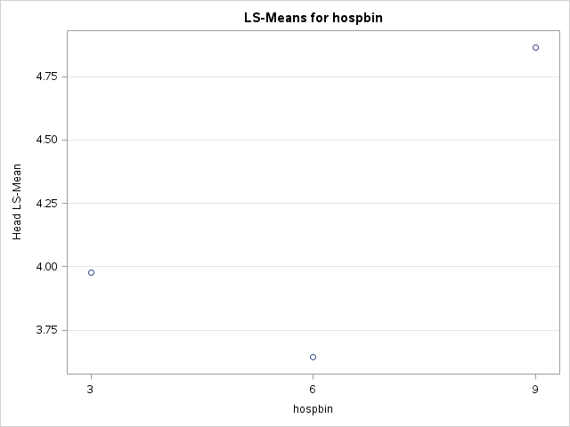

| hospbin | Body LSMEAN |
| --- | --- |
| 3 | 4.21742319 |
| 6 | 4.17155869 |
| 9 | 4.61384008 |

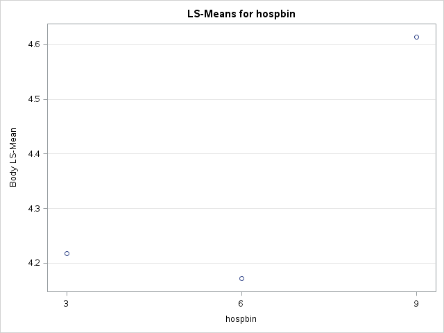

| hospbin | Tail LSMEAN |
| --- | --- |
| 3 | 5.35137056 |
| 6 | 4.70966214 |
| 9 | 5.66879708 |

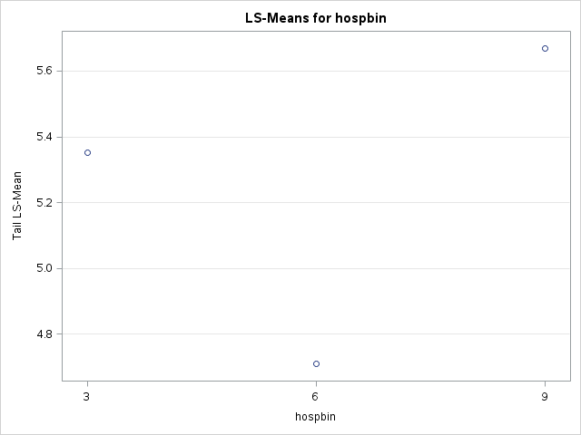

| age_group | Head LSMEAN |
| --- | --- |
| 1 | 4.49802806 |
| 2 | 3.47979117 |
| 3 | 4.50648312 |

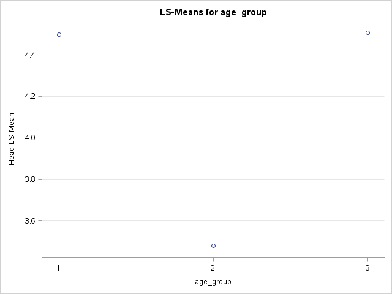

| age_group | Body LSMEAN |
| --- | --- |
| 1 | 4.37508161 |
| 2 | 3.28959667 |
| 3 | 5.33814369 |

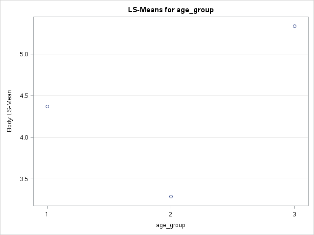

| age_group | Tail LSMEAN |
| --- | --- |
| 1 | 4.55677139 |
| 2 | 4.76605417 |
| 3 | 6.40700423 |

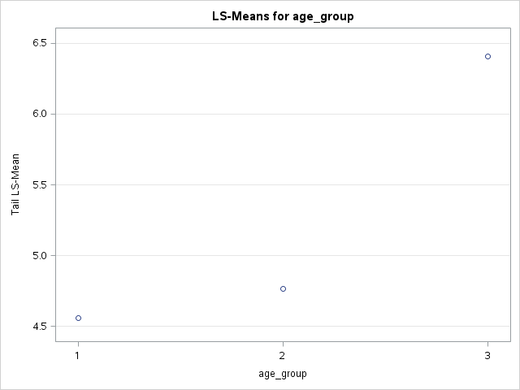

| hospbin | age_group | Head LSMEAN |
| --- | --- | --- |
| 3 | 1 | 3.46834667 |
| 3 | 2 | 5.05541500 |
| 3 | 3 | 3.40523250 |
| 6 | 1 | 4.36122750 |
| 6 | 2 | 2.08444850 |
| 6 | 3 | 4.48517186 |
| 9 | 1 | 5.66451000 |
| 9 | 2 | 3.29951000 |
| 9 | 3 | 5.62904500 |

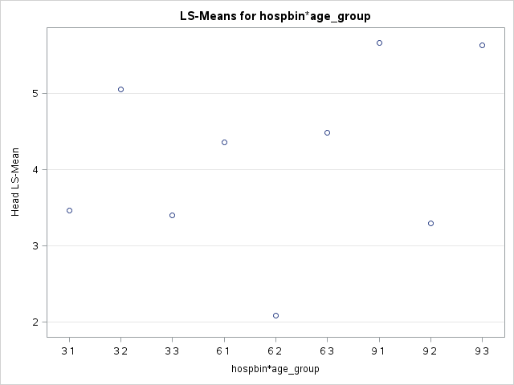

| hospbin | age_group | Body LSMEAN |
| --- | --- | --- |
| 3 | 1 | 3.52531333 |
| 3 | 2 | 5.50029000 |
| 3 | 3 | 3.62666625 |
| 6 | 1 | 4.99802750 |
| 6 | 2 | 1.68586000 |
| 6 | 3 | 5.83078857 |
| 9 | 1 | 4.60190400 |
| 9 | 2 | 2.68264000 |
| 9 | 3 | 6.55697625 |

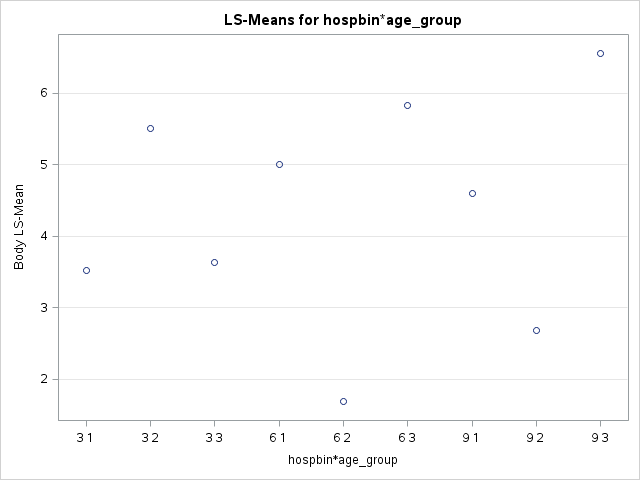

| hospbin | age_group | Tail LSMEAN |
| --- | --- | --- |
| 3 | 1 | 4.18222667 |
| 3 | 2 | 7.61160000 |
| 3 | 3 | 4.26028500 |
| 6 | 1 | 4.56364250 |
| 6 | 2 | 1.84092250 |
| 6 | 3 | 7.72442143 |
| 9 | 1 | 4.92444500 |
| 9 | 2 | 4.84564000 |
| 9 | 3 | 7.23630625 |

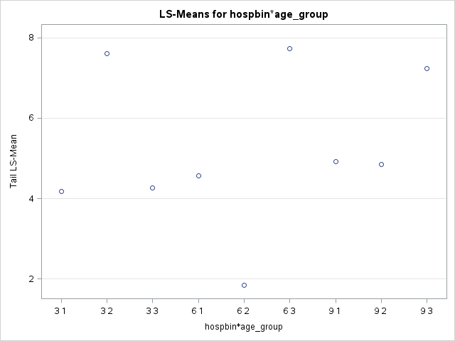

The SAS System

The Mixed Procedure

| Model Information |  |
| --- | --- |
| Data Set | WORK.CD45 |
| Dependent Variable | percent_cd45 |
| Covariance Structure | Unstructured |
| Subject Effect | Case(hospbin) |
| Estimation Method | REML |
| Residual Variance Method | None |
| Fixed Effects SE Method | Model-Based |
| Degrees of Freedom Method | Between-Within |

| Class Level Information Class | Class Level Information Levels | Class Level Information Values |
| --- | --- | --- |
| Case | 39 | 6003 6005 6007 6008 6011 6019 6047 6048 6057 6060 6073 6099 6104 6106 6115 6117 6126 6129 6131 6134 6140 6144 6162 6165 6172 6174 6178 6179 6187 6200 6219 6229 6230 6235 6250 6251 6254 6278 6279 |
| hospbin | 3 | 3 6 9 |
| age_group | 3 | 1 2 3 |
| sample_type2 | 3 | A B C |

| Dimensions |  |
| --- | --- |
| Covariance Parameters | 6 |
| Columns in X | 64 |
| Columns in Z | 0 |
| Subjects | 39 |
| Max Obs per Subject | 3 |

| Number of Observations |  |
| --- | --- |
| Number of Observations Read | 117 |
| Number of Observations Used | 117 |
| Number of Observations Not Used | 0 |

| Iteration History Iteration | Iteration History Evaluations | Iteration History -2 Res Log Like | Iteration History Criterion |
| --- | --- | --- | --- |
| 0 | 1 | 527.51353740 |  |
| 1 | 1 | 405.87052007 | 0.00000000 |

| Convergence criteria met. |
| --- |

| Covariance Parameter Estimates Cov Parm | Covariance Parameter Estimates Subject | Covariance Parameter Estimates Estimate |
| --- | --- | --- |
| UN(1,1) | Case(hospbin) | 9.5215 |
| UN(2,1) | Case(hospbin) | 9.2874 |
| UN(2,2) | Case(hospbin) | 12.4230 |
| UN(3,1) | Case(hospbin) | 12.4988 |
| UN(3,2) | Case(hospbin) | 15.0169 |
| UN(3,3) | Case(hospbin) | 20.2907 |

| Fit Statistics |  |
| --- | --- |
| -2 Res Log Likelihood | 405.9 |
| AIC (Smaller is Better) | 417.9 |
| AICC (Smaller is Better) | 418.9 |
| BIC (Smaller is Better) | 427.9 |

| Null Model Likelihood Ratio Test DF | Null Model Likelihood Ratio Test Chi-Square | Null Model Likelihood Ratio Test Pr > ChiSq |
| --- | --- | --- |
| 5 | 121.64 | <.0001 |

| Type 3 Tests of Fixed Effects Effect | Type 3 Tests of Fixed Effects Num DF | Type 3 Tests of Fixed Effects Den DF | Type 3 Tests of Fixed Effects F Value | Type 3 Tests of Fixed Effects Pr > F |
| --- | --- | --- | --- | --- |
| hospbin | 2 | 30 | 0.12 | 0.8893 |
| age_group | 2 | 30 | 0.50 | 0.6107 |
| hospbin*age_group | 4 | 30 | 0.70 | 0.6009 |
| sample_type2 | 2 | 30 | 4.44 | 0.0205 |
| hospbin*sample_type2 | 4 | 30 | 0.32 | 0.8594 |
| age_group*sample_typ | 4 | 30 | 1.58 | 0.2064 |
| hospbi*age_gr*sample | 8 | 30 | 1.02 | 0.4432 |

| Least Squares Means Effect | Least Squares Means sample_type2 | Least Squares Means hospbin | Least Squares Means age_group | Least Squares Means Estimate | Least Squares Means Standard Error | Least Squares Means DF | Least Squares Means t Value | Least Squares Means Pr > \|t\| | Least Squares Means Alpha | Least Squares Means Lower | Least Squares Means Upper |
| --- | --- | --- | --- | --- | --- | --- | --- | --- | --- | --- | --- |
| hospbin |  | 3 |  | 4.5150 | 1.1707 | 30 | 3.86 | 0.0006 | 0.05 | 2.1241 | 6.9059 |
| hospbin |  | 6 |  | 4.1749 | 1.1300 | 30 | 3.69 | 0.0009 | 0.05 | 1.8672 | 6.4827 |
| hospbin |  | 9 |  | 5.0490 | 1.4023 | 30 | 3.60 | 0.0011 | 0.05 | 2.1851 | 7.9129 |
| age_group |  |  | 1 | 4.4766 | 1.0917 | 30 | 4.10 | 0.0003 | 0.05 | 2.2471 | 6.7062 |
| age_group |  |  | 2 | 3.8451 | 1.6912 | 30 | 2.27 | 0.0303 | 0.05 | 0.3912 | 7.2991 |
| age_group |  |  | 3 | 5.4172 | 0.7496 | 30 | 7.23 | <.0001 | 0.05 | 3.8864 | 6.9480 |
| hospbin*age_group |  | 3 | 1 | 3.7253 | 2.0713 | 30 | 1.80 | 0.0822 | 0.05 | -0.5049 | 7.9555 |
| hospbin*age_group |  | 3 | 2 | 6.0558 | 2.5369 | 30 | 2.39 | 0.0235 | 0.05 | 0.8748 | 11.2367 |
| hospbin*age_group |  | 3 | 3 | 3.7641 | 1.2684 | 30 | 2.97 | 0.0058 | 0.05 | 1.1736 | 6.3545 |
| hospbin*age_group |  | 6 | 1 | 4.6410 | 1.7938 | 30 | 2.59 | 0.0148 | 0.05 | 0.9775 | 8.3044 |
| hospbin*age_group |  | 6 | 2 | 1.8704 | 2.5369 | 30 | 0.74 | 0.4667 | 0.05 | -3.3105 | 7.0514 |
| hospbin*age_group |  | 6 | 3 | 6.0135 | 1.3560 | 30 | 4.43 | 0.0001 | 0.05 | 3.2441 | 8.7828 |
| hospbin*age_group |  | 9 | 1 | 5.0636 | 1.7938 | 30 | 2.82 | 0.0084 | 0.05 | 1.4001 | 8.7271 |
| hospbin*age_group |  | 9 | 2 | 3.6093 | 3.5877 | 30 | 1.01 | 0.3225 | 0.05 | -3.7177 | 10.9362 |
| hospbin*age_group |  | 9 | 3 | 6.4741 | 1.2684 | 30 | 5.10 | <.0001 | 0.05 | 3.8836 | 9.0646 |
| sample_type2 | A |  |  | 4.1614 | 0.6158 | 30 | 6.76 | <.0001 | 0.05 | 2.9038 | 5.4191 |
| sample_type2 | B |  |  | 4.3343 | 0.7034 | 30 | 6.16 | <.0001 | 0.05 | 2.8977 | 5.7709 |
| sample_type2 | C |  |  | 5.2433 | 0.8990 | 30 | 5.83 | <.0001 | 0.05 | 3.4073 | 7.0792 |
| hospbin*sample_type2 | A | 3 |  | 3.9763 | 1.0069 | 30 | 3.95 | 0.0004 | 0.05 | 1.9200 | 6.0327 |
| hospbin*sample_type2 | B | 3 |  | 4.2174 | 1.1501 | 30 | 3.67 | 0.0009 | 0.05 | 1.8685 | 6.5663 |
| hospbin*sample_type2 | C | 3 |  | 5.3514 | 1.4699 | 30 | 3.64 | 0.0010 | 0.05 | 2.3494 | 8.3533 |
| hospbin*sample_type2 | A | 6 |  | 3.6436 | 0.9719 | 30 | 3.75 | 0.0008 | 0.05 | 1.6587 | 5.6285 |
| hospbin*sample_type2 | B | 6 |  | 4.1716 | 1.1102 | 30 | 3.76 | 0.0007 | 0.05 | 1.9043 | 6.4388 |
| hospbin*sample_type2 | C | 6 |  | 4.7097 | 1.4188 | 30 | 3.32 | 0.0024 | 0.05 | 1.8121 | 7.6072 |
| hospbin*sample_type2 | A | 9 |  | 4.8644 | 1.2061 | 30 | 4.03 | 0.0003 | 0.05 | 2.4012 | 7.3275 |
| hospbin*sample_type2 | B | 9 |  | 4.6138 | 1.3777 | 30 | 3.35 | 0.0022 | 0.05 | 1.8003 | 7.4274 |
| hospbin*sample_type2 | C | 9 |  | 5.6688 | 1.7607 | 30 | 3.22 | 0.0031 | 0.05 | 2.0730 | 9.2646 |
| age_group*sample_typ | A |  | 1 | 4.4980 | 0.9389 | 30 | 4.79 | <.0001 | 0.05 | 2.5804 | 6.4156 |
| age_group*sample_typ | B |  | 1 | 4.3751 | 1.0725 | 30 | 4.08 | 0.0003 | 0.05 | 2.1847 | 6.5654 |
| age_group*sample_typ | C |  | 1 | 4.5568 | 1.3707 | 30 | 3.32 | 0.0023 | 0.05 | 1.7575 | 7.3561 |
| age_group*sample_typ | A |  | 2 | 3.4798 | 1.4546 | 30 | 2.39 | 0.0232 | 0.05 | 0.5091 | 6.4505 |
| age_group*sample_typ | B |  | 2 | 3.2896 | 1.6615 | 30 | 1.98 | 0.0570 | 0.05 | -0.1037 | 6.6829 |
| age_group*sample_typ | C |  | 2 | 4.7661 | 2.1235 | 30 | 2.24 | 0.0323 | 0.05 | 0.4294 | 9.1027 |
| age_group*sample_typ | A |  | 3 | 4.5065 | 0.6447 | 30 | 6.99 | <.0001 | 0.05 | 3.1899 | 5.8231 |
| age_group*sample_typ | B |  | 3 | 5.3381 | 0.7364 | 30 | 7.25 | <.0001 | 0.05 | 3.8342 | 6.8421 |
| age_group*sample_typ | C |  | 3 | 6.4070 | 0.9411 | 30 | 6.81 | <.0001 | 0.05 | 4.4850 | 8.3290 |
| hospbi*age_gr*sample | A | 3 | 1 | 3.4683 | 1.7815 | 30 | 1.95 | 0.0610 | 0.05 | -0.1700 | 7.1067 |
| hospbi*age_gr*sample | B | 3 | 1 | 3.5253 | 2.0349 | 30 | 1.73 | 0.0935 | 0.05 | -0.6306 | 7.6812 |
| hospbi*age_gr*sample | C | 3 | 1 | 4.1822 | 2.6007 | 30 | 1.61 | 0.1183 | 0.05 | -1.1291 | 9.4935 |
| hospbi*age_gr*sample | A | 3 | 2 | 5.0554 | 2.1819 | 30 | 2.32 | 0.0275 | 0.05 | 0.5994 | 9.5115 |
| hospbi*age_gr*sample | B | 3 | 2 | 5.5003 | 2.4923 | 30 | 2.21 | 0.0351 | 0.05 | 0.4104 | 10.5902 |
| hospbi*age_gr*sample | C | 3 | 2 | 7.6116 | 3.1852 | 30 | 2.39 | 0.0233 | 0.05 | 1.1066 | 14.1166 |
| hospbi*age_gr*sample | A | 3 | 3 | 3.4052 | 1.0910 | 30 | 3.12 | 0.0040 | 0.05 | 1.1772 | 5.6333 |
| hospbi*age_gr*sample | B | 3 | 3 | 3.6267 | 1.2461 | 30 | 2.91 | 0.0067 | 0.05 | 1.0817 | 6.1716 |
| hospbi*age_gr*sample | C | 3 | 3 | 4.2603 | 1.5926 | 30 | 2.68 | 0.0120 | 0.05 | 1.0078 | 7.5128 |
| hospbi*age_gr*sample | A | 6 | 1 | 4.3612 | 1.5428 | 30 | 2.83 | 0.0083 | 0.05 | 1.2103 | 7.5121 |
| hospbi*age_gr*sample | B | 6 | 1 | 4.9980 | 1.7623 | 30 | 2.84 | 0.0081 | 0.05 | 1.3989 | 8.5972 |
| hospbi*age_gr*sample | C | 6 | 1 | 4.5636 | 2.2523 | 30 | 2.03 | 0.0517 | 0.05 | -0.03609 | 9.1634 |
| hospbi*age_gr*sample | A | 6 | 2 | 2.0844 | 2.1819 | 30 | 0.96 | 0.3470 | 0.05 | -2.3716 | 6.5405 |
| hospbi*age_gr*sample | B | 6 | 2 | 1.6859 | 2.4923 | 30 | 0.68 | 0.5039 | 0.05 | -3.4041 | 6.7758 |
| hospbi*age_gr*sample | C | 6 | 2 | 1.8409 | 3.1852 | 30 | 0.58 | 0.5676 | 0.05 | -4.6641 | 8.3459 |
| hospbi*age_gr*sample | A | 6 | 3 | 4.4852 | 1.1663 | 30 | 3.85 | 0.0006 | 0.05 | 2.1033 | 6.8670 |
| hospbi*age_gr*sample | B | 6 | 3 | 5.8308 | 1.3322 | 30 | 4.38 | 0.0001 | 0.05 | 3.1101 | 8.5515 |
| hospbi*age_gr*sample | C | 6 | 3 | 7.7244 | 1.7025 | 30 | 4.54 | <.0001 | 0.05 | 4.2474 | 11.2015 |
| hospbi*age_gr*sample | A | 9 | 1 | 5.6645 | 1.5428 | 30 | 3.67 | 0.0009 | 0.05 | 2.5136 | 8.8154 |
| hospbi*age_gr*sample | B | 9 | 1 | 4.6019 | 1.7623 | 30 | 2.61 | 0.0139 | 0.05 | 1.0028 | 8.2010 |
| hospbi*age_gr*sample | C | 9 | 1 | 4.9244 | 2.2523 | 30 | 2.19 | 0.0367 | 0.05 | 0.3247 | 9.5242 |
| hospbi*age_gr*sample | A | 9 | 2 | 3.2995 | 3.0857 | 30 | 1.07 | 0.2935 | 0.05 | -3.0023 | 9.6013 |
| hospbi*age_gr*sample | B | 9 | 2 | 2.6826 | 3.5246 | 30 | 0.76 | 0.4525 | 0.05 | -4.5156 | 9.8809 |
| hospbi*age_gr*sample | C | 9 | 2 | 4.8456 | 4.5045 | 30 | 1.08 | 0.2906 | 0.05 | -4.3538 | 14.0451 |
| hospbi*age_gr*sample | A | 9 | 3 | 5.6290 | 1.0910 | 30 | 5.16 | <.0001 | 0.05 | 3.4010 | 7.8571 |
| hospbi*age_gr*sample | B | 9 | 3 | 6.5570 | 1.2461 | 30 | 5.26 | <.0001 | 0.05 | 4.0120 | 9.1019 |
| hospbi*age_gr*sample | C | 9 | 3 | 7.2363 | 1.5926 | 30 | 4.54 | <.0001 | 0.05 | 3.9838 | 10.4888 |

| Differences of Least Squares Means Effect | Differences of Least Squares Means sample_type2 | Differences of Least Squares Means hospbin | Differences of Least Squares Means age_group | Differences of Least Squares Means _sample_type2 | Differences of Least Squares Means hospbin | Differences of Least Squares Means _age_group | Differences of Least Squares Means Estimate | Differences of Least Squares Means Standard Error | Differences of Least Squares Means DF | Differences of Least Squares Means t Value | Differences of Least Squares Means Pr > \|t\| | Differences of Least Squares Means Adjustment | Differences of Least Squares Means Adj P | Differences of Least Squares Means Alpha | Differences of Least Squares Means Lower | Differences of Least Squares Means Upper | Differences of Least Squares Means Adj Lower | Differences of Least Squares Means Adj Upper |
| --- | --- | --- | --- | --- | --- | --- | --- | --- | --- | --- | --- | --- | --- | --- | --- | --- | --- | --- |
| hospbin |  | 3 |  |  | 6 |  | 0.3401 | 1.6271 | 30 | 0.21 | 0.8358 | Tukey-Kramer | 0.9762 | 0.05 | -2.9829 | 3.6631 | -3.6711 | 4.3513 |
| hospbin |  | 3 |  |  | 9 |  | -0.5340 | 1.8267 | 30 | -0.29 | 0.7721 | Tukey-Kramer | 0.9541 | 0.05 | -4.2647 | 3.1968 | -5.0373 | 3.9694 |
| hospbin |  | 6 |  |  | 9 |  | -0.8741 | 1.8009 | 30 | -0.49 | 0.6310 | Tukey-Kramer | 0.8788 | 0.05 | -4.5520 | 2.8039 | -5.3138 | 3.5657 |
| age_group |  |  | 1 |  |  | 2 | 0.6315 | 2.0130 | 30 | 0.31 | 0.7559 | Tukey-Kramer | 0.9473 | 0.05 | -3.4796 | 4.7425 | -4.3310 | 5.5940 |
| age_group |  |  | 1 |  |  | 3 | -0.9406 | 1.3242 | 30 | -0.71 | 0.4830 | Tukey-Kramer | 0.7593 | 0.05 | -3.6451 | 1.7639 | -4.2052 | 2.3240 |
| age_group |  |  | 2 |  |  | 3 | -1.5721 | 1.8499 | 30 | -0.85 | 0.4022 | Tukey-Kramer | 0.6755 | 0.05 | -5.3501 | 2.2059 | -6.1325 | 2.9884 |
| hospbin*age_group |  | 3 | 1 |  | 3 | 2 | -2.3305 | 3.2751 | 30 | -0.71 | 0.4822 | Tukey-Kramer | 0.9982 | 0.05 | -9.0190 | 4.3581 | -13.2610 | 8.6001 |
| hospbin*age_group |  | 3 | 1 |  | 3 | 3 | -0.03877 | 2.4289 | 30 | -0.02 | 0.9874 | Tukey-Kramer | 1.0000 | 0.05 | -4.9991 | 4.9216 | -8.1451 | 8.0675 |
| hospbin*age_group |  | 3 | 1 |  | 6 | 1 | -0.9157 | 2.7401 | 30 | -0.33 | 0.7406 | Tukey-Kramer | 1.0000 | 0.05 | -6.5117 | 4.6804 | -10.0608 | 8.2295 |
| hospbin*age_group |  | 3 | 1 |  | 6 | 2 | 1.8549 | 3.2751 | 30 | 0.57 | 0.5754 | Tukey-Kramer | 0.9997 | 0.05 | -4.8337 | 8.5435 | -9.0756 | 12.7854 |
| hospbin*age_group |  | 3 | 1 |  | 6 | 3 | -2.2882 | 2.4757 | 30 | -0.92 | 0.3627 | Tukey-Kramer | 0.9896 | 0.05 | -7.3443 | 2.7679 | -10.5509 | 5.9745 |
| hospbin*age_group |  | 3 | 1 |  | 9 | 1 | -1.3383 | 2.7401 | 30 | -0.49 | 0.6288 | Tukey-Kramer | 0.9999 | 0.05 | -6.9344 | 4.2577 | -10.4835 | 7.8068 |
| hospbin*age_group |  | 3 | 1 |  | 9 | 2 | 0.1160 | 4.1427 | 30 | 0.03 | 0.9778 | Tukey-Kramer | 1.0000 | 0.05 | -8.3444 | 8.5765 | -13.7101 | 13.9422 |
| hospbin*age_group |  | 3 | 1 |  | 9 | 3 | -2.7488 | 2.4289 | 30 | -1.13 | 0.2667 | Tukey-Kramer | 0.9643 | 0.05 | -7.7092 | 2.2116 | -10.8551 | 5.3575 |
| hospbin*age_group |  | 3 | 2 |  | 3 | 3 | 2.2917 | 2.8363 | 30 | 0.81 | 0.4255 | Tukey-Kramer | 0.9957 | 0.05 | -3.5008 | 8.0842 | -7.1744 | 11.7578 |
| hospbin*age_group |  | 3 | 2 |  | 6 | 1 | 1.4148 | 3.1070 | 30 | 0.46 | 0.6521 | Tukey-Kramer | 0.9999 | 0.05 | -4.9305 | 7.7601 | -8.9548 | 11.7844 |
| hospbin*age_group |  | 3 | 2 |  | 6 | 2 | 4.1854 | 3.5877 | 30 | 1.17 | 0.2526 | Tukey-Kramer | 0.9575 | 0.05 | -3.1416 | 11.5123 | -7.7884 | 16.1592 |
| hospbin*age_group |  | 3 | 2 |  | 6 | 3 | 0.04231 | 2.8765 | 30 | 0.01 | 0.9884 | Tukey-Kramer | 1.0000 | 0.05 | -5.8323 | 5.9170 | -9.5581 | 9.6427 |
| hospbin*age_group |  | 3 | 2 |  | 9 | 1 | 0.9921 | 3.1070 | 30 | 0.32 | 0.7517 | Tukey-Kramer | 1.0000 | 0.05 | -5.3532 | 7.3375 | -9.3775 | 11.3618 |
| hospbin*age_group |  | 3 | 2 |  | 9 | 2 | 2.4465 | 4.3940 | 30 | 0.56 | 0.5818 | Tukey-Kramer | 0.9997 | 0.05 | -6.5272 | 11.4202 | -12.2183 | 17.1114 |
| hospbin*age_group |  | 3 | 2 |  | 9 | 3 | -0.4183 | 2.8363 | 30 | -0.15 | 0.8837 | Tukey-Kramer | 1.0000 | 0.05 | -6.2108 | 5.3741 | -9.8845 | 9.0478 |
| hospbin*age_group |  | 3 | 3 |  | 6 | 1 | -0.8769 | 2.1970 | 30 | -0.40 | 0.6926 | Tukey-Kramer | 1.0000 | 0.05 | -5.3637 | 3.6099 | -8.2093 | 6.4555 |
| hospbin*age_group |  | 3 | 3 |  | 6 | 2 | 1.8937 | 2.8363 | 30 | 0.67 | 0.5095 | Tukey-Kramer | 0.9989 | 0.05 | -3.8988 | 7.6861 | -7.5725 | 11.3598 |
| hospbin*age_group |  | 3 | 3 |  | 6 | 3 | -2.2494 | 1.8568 | 30 | -1.21 | 0.2352 | Tukey-Kramer | 0.9476 | 0.05 | -6.0415 | 1.5427 | -8.4464 | 3.9476 |
| hospbin*age_group |  | 3 | 3 |  | 9 | 1 | -1.2996 | 2.1970 | 30 | -0.59 | 0.5586 | Tukey-Kramer | 0.9995 | 0.05 | -5.7864 | 3.1873 | -8.6320 | 6.0329 |
| hospbin*age_group |  | 3 | 3 |  | 9 | 2 | 0.1548 | 3.8053 | 30 | 0.04 | 0.9678 | Tukey-Kramer | 1.0000 | 0.05 | -7.6166 | 7.9262 | -12.5453 | 12.8549 |
| hospbin*age_group |  | 3 | 3 |  | 9 | 3 | -2.7100 | 1.7938 | 30 | -1.51 | 0.1413 | Tukey-Kramer | 0.8418 | 0.05 | -6.3735 | 0.9534 | -8.6969 | 3.2769 |
| hospbin*age_group |  | 6 | 1 |  | 6 | 2 | 2.7706 | 3.1070 | 30 | 0.89 | 0.3796 | Tukey-Kramer | 0.9918 | 0.05 | -3.5748 | 9.1159 | -7.5991 | 13.1402 |
| hospbin*age_group |  | 6 | 1 |  | 6 | 3 | -1.3725 | 2.2487 | 30 | -0.61 | 0.5462 | Tukey-Kramer | 0.9994 | 0.05 | -5.9649 | 3.2199 | -8.8775 | 6.1325 |
| hospbin*age_group |  | 6 | 1 |  | 9 | 1 | -0.4227 | 2.5369 | 30 | -0.17 | 0.8688 | Tukey-Kramer | 1.0000 | 0.05 | -5.6036 | 4.7583 | -8.8894 | 8.0441 |

[output cut: 438 more lines]

```sas
/*to perform sphericity tests and model p-values*/

PROC glm data=cd45_no_insulin;
     class hospbin age_group;
     model Head Body Tail= hospbin|age_group /nouni;
         *nouni to suppress display of univariate stats;
         *solution not used to display parameter estimates;
         *clparm not used to display confidence limits for parameter estimates;
     repeated sample_type2 / short printe;
         *short for abbreviated version of output;
         *printe provides e matrix, sphericity tests, partial correlations;
     lsmeans hospbin|age_group / out=cd45_lsmeans (drop=stderr);
run;
quit;



/*to obtain all LSmeans and SE values, perform individual comparisons, retrieve differences and assoc. confidence intervals*/
ods output diffs=cd45_lsmeans_diff;

PROC mixed data=cd45;
     class case hospbin age_group sample_type2;
     model percent_cd45=hospbin|age_group|sample_type2;
     repeated sample_type2/ subject=case(hospbin) type=un;
     lsmeans hospbin|age_group|sample_type2 /adjust=tukey cl pdiff alpha=0.05;
run;

ods output close;
```

Data for supplemental table 2 and Figure 1

```sas
/*ls means values by head body and tail*/

DATA cd45_lsmeans1 (drop=age_group);
     set cd45_lsmeans;
     if age_group^="" then delete;
     stain="CD45           ";
     rename _NAME_=pancreas_region;
run;

PROC print data=cd45_lsmeans1;
run;

/*grand mean values*/

PROC means data=cd45_lsmeans1 mean;
     var lsmean;
     class hospbin;
     output out=cd45_grandmean;
run;

DATA cd45_grandmean (drop=_type_ _freq_ _stat_);
     set cd45_grandmean;
     if _stat_^="MEAN" then delete;
     if hospbin="" then delete;
     pancreas_region="Overall";
     stain="CD45           ";
run;

/*combine files into 1*/

DATA cd45_fig1;
     set cd45_lsmeans1 cd45_grandmean;
run;

PROC print data=cd45_fig1;
run;
```

The SAS System

| Obs | pancreas_region | hospbin | LSMEAN | stain |
| --- | --- | --- | --- | --- |
| 1 | Head | 3 | 3.97633 | CD45 |
| 2 | Head | 6 | 3.64362 | CD45 |
| 3 | Head | 9 | 4.86435 | CD45 |
| 4 | Body | 3 | 4.21742 | CD45 |
| 5 | Body | 6 | 4.17156 | CD45 |
| 6 | Body | 9 | 4.61384 | CD45 |
| 7 | Tail | 3 | 5.35137 | CD45 |
| 8 | Tail | 6 | 4.70966 | CD45 |
| 9 | Tail | 9 | 5.66880 | CD45 |

The SAS System

The MEANS Procedure

| Analysis Variable : LSMEAN hospbin | Analysis Variable : LSMEAN N Obs | Analysis Variable : LSMEAN Mean |
| --- | --- | --- |
| 3 | 3 | 4.5150417 |
| 6 | 3 | 4.1749456 |
| 9 | 3 | 5.0489974 |

The SAS System

| Obs | pancreas_region | hospbin | LSMEAN | stain |
| --- | --- | --- | --- | --- |
| 1 | Head | 3 | 3.97633 | CD45 |
| 2 | Head | 6 | 3.64362 | CD45 |
| 3 | Head | 9 | 4.86435 | CD45 |
| 4 | Body | 3 | 4.21742 | CD45 |
| 5 | Body | 6 | 4.17156 | CD45 |
| 6 | Body | 9 | 4.61384 | CD45 |
| 7 | Tail | 3 | 5.35137 | CD45 |
| 8 | Tail | 6 | 4.70966 | CD45 |
| 9 | Tail | 9 | 5.66880 | CD45 |
| 10 | Overall | 3 | 4.51504 | CD45 |
| 11 | Overall | 6 | 4.17495 | CD45 |
| 12 | Overall | 9 | 5.04900 | CD45 |

Data for figure 2

Figure 2A generation

```sas
/*boxplots of staining levels grouped by panc region*/

PROC sort data=cd45;
    by sample_type2;
run;

PROC means data=cd45 mean std median min max;
     var percent_cd45;
     by sample_type2;
run;

DATA long_cd45;
     set cd45;
     stain="CD45     ";
     percent_cells=percent_cd45;
output;

     stain="Insulin";
        percent_cells=percent_insulin;
output;

     stain="Negative";
     percent_cells=percent_negative;
output;

     drop percent_cd45 percent_insulin percent_negative;
run;
```

The SAS System

The MEANS Procedure

sample_type2=A

| Analysis Variable : percent_cd45 %% CD45 Positive Cells Mean | Analysis Variable : percent_cd45 %% CD45 Positive Cells Std Dev | Analysis Variable : percent_cd45 %% CD45 Positive Cells Median | Analysis Variable : percent_cd45 %% CD45 Positive Cells Minimum | Analysis Variable : percent_cd45 %% CD45 Positive Cells Maximum |
| --- | --- | --- | --- | --- |
| 4.4040423 | 2.9356949 | 3.6430000 | 0.4548470 | 12.3875000 |

sample_type2=B

| Analysis Variable : percent_cd45 %% CD45 Positive Cells Mean | Analysis Variable : percent_cd45 %% CD45 Positive Cells Std Dev | Analysis Variable : percent_cd45 %% CD45 Positive Cells Median | Analysis Variable : percent_cd45 %% CD45 Positive Cells Minimum | Analysis Variable : percent_cd45 %% CD45 Positive Cells Maximum |
| --- | --- | --- | --- | --- |
| 4.8285966 | 3.4253421 | 4.1014500 | 0.4878000 | 16.1682000 |

sample_type2=C

| Analysis Variable : percent_cd45 %% CD45 Positive Cells Mean | Analysis Variable : percent_cd45 %% CD45 Positive Cells Std Dev | Analysis Variable : percent_cd45 %% CD45 Positive Cells Median | Analysis Variable : percent_cd45 %% CD45 Positive Cells Minimum | Analysis Variable : percent_cd45 %% CD45 Positive Cells Maximum |
| --- | --- | --- | --- | --- |
| 5.6485486 | 4.3681732 | 4.5529300 | 0.5273950 | 18.4238000 |

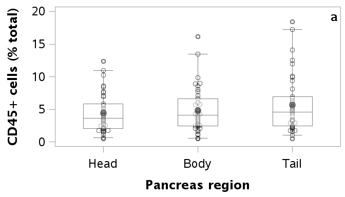

```sas
ODS GRAPHICS ON / reset = all height= 4 in width=7 in border= off imagename="Fig2A";
ods listing image_dpi=600;

PROC sgplot data=long_cd45 (where=(stain = 'CD45')) noautolegend;
     format sample_type2 $pancorder.;
     styleattrs datacolors=(white) datacontrastcolors=(black);
     scatter x=sample_type2 y=percent_cells/ group=stain name="Circles" jitter MARKERATTRS=(symbol=circle size=10) MARKEROUTLINEATTRS=(thickness=1) transparency=0.4;
     vbox percent_cells / whiskerpct=5 /*95% percentile*/ category=sample_type2 group=stain transparency=0.50 meanattrs=(color=black symbol=circlefilled size=14) fillattrs=(color=white transparency=.5);
     yaxis grid;
     xaxis discreteorder=data labelattrs=(size=18) valueattrs=(size=18) label="Pancreas region" labelattrs=(size = 19 Family=Arial weight=bold);

     yaxis values=(0 to 20 by 5) labelattrs=(size=18) valueattrs=(size=18) label="CD45+ cells (% total)" labelattrs = (size = 19 Family=Arial weight=bold);
     inset /title= "a" titleattrs=(size=19) titleattrs=(weight=bold) position=topright noborder;
run;

ODS GRAPHICS off;
```

Figure 2B generation. Code for figure adapoted from Robin High, University of Nebraska Medical Center and is available [here.](http://support.sas.com/resources/papers/proceedings14/1902-2014.pdf)

```sas
/*need to prepare data file*/

DATA differences (drop=hospbin _hospbin age_group _age_group);
     format sample_type2 $pancorder. _sample_type2 $pancorder.;
     set cd45_lsmeans_diff;
     if effect^="sample_type2" then delete;
     if sample_type2="A" then region1="Head";
     if sample_type2="B" then region1="Body";
     if sample_type2="C" then region1="Tail";
     if _sample_type2="A" then region2="Head";
     if _sample_type2="B" then region2="Body";
     if _sample_type2="C" then region2="Tail";
run;

PROC print data=differences;
run;
```

The SAS System

| Obs | sample_type2 | _sample_type2 | Effect | Estimate | StdErr | DF | tValue | Probt | Adjustment | Adjp | Alpha | Lower | Upper | AdjLower | AdjUpper | region1 | region2 |
| --- | --- | --- | --- | --- | --- | --- | --- | --- | --- | --- | --- | --- | --- | --- | --- | --- | --- |
| 1 | Head | Body | sample_type2 | -0.1728 | 0.3664 | 30 | -0.47 | 0.6405 | Tukey-Kramer | 0.8850 | 0.05 | -0.9210 | 0.5754 | -1.0760 | 0.7303 | Head | Body |
| 2 | Head | Tail | sample_type2 | -1.0818 | 0.4379 | 30 | -2.47 | 0.0194 | Tukey-Kramer | 0.0494 | 0.05 | -1.9762 | -0.1875 | -2.1614 | -0.00230 | Head | Tail |
| 3 | Body | Tail | sample_type2 | -0.9090 | 0.3267 | 30 | -2.78 | 0.0092 | Tukey-Kramer | 0.0244 | 0.05 | -1.5762 | -0.2418 | -1.7144 | -0.1036 | Body | Tail |

The SAS System

| Obs | sample_type2 | _sample_type2 | Effect | mndif1 | StdErr | DF | tValue | Probt | Adjustment | Adjp | Alpha | Lower | Upper | adjlower1 | adjupper1 | region1 | region2 | label | pvalue | mndif2 | adjlower2 | adjupper2 |
| --- | --- | --- | --- | --- | --- | --- | --- | --- | --- | --- | --- | --- | --- | --- | --- | --- | --- | --- | --- | --- | --- | --- |
| 1 | Head | Body | sample_type2 | -0.1728 | 0.3664 | 30 | -0.47 | 0.6405 | Tukey-Kramer | 0.8850 | 0.05 | -0.9210 | 0.5754 | -1.0760 | 0.7303 | Head | Body | Head vs Body | . | . | . | . |
| 2 | Head | Tail | sample_type2 | -1.0818 | 0.4379 | 30 | -2.47 | 0.0194 | Tukey-Kramer | 0.0494 | 0.05 | -1.9762 | -0.1875 | -2.1614 | -0.00230 | Head | Tail | Head vs Tail | . | . | . | . |
| 3 | Body | Tail | sample_type2 | -0.9090 | 0.3267 | 30 | -2.78 | 0.0092 | Tukey-Kramer | 0.0244 | 0.05 | -1.5762 | -0.2418 | -1.7144 | -0.1036 | Body | Tail | Body vs Tail | . | . | . | . |

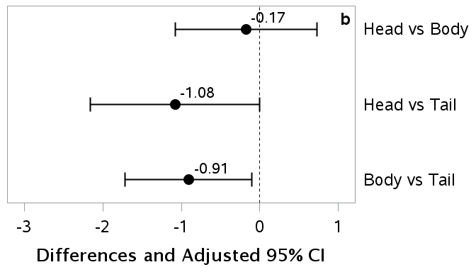

```sas
/* Forest Plot of Differences
with the file of differences add a text variable called label describing each comparison;*/
DATA dfs2;
     SET differences (rename=(estimate=mndif1 adjlower=adjlower1 adjupper=adjupper1));
     DROP ptxt;
     LENGTH label $30 ptxt $4;
     IF pvalue < .001 then ptxt=', p='; else ptxt=', p=';
     label = CAT(put(region1,4.),' vs ',
     put(region2,4.));
     * new variables for non-significant differences, set existing to missing;
     IF (pvalue GE 0.05) then do;
     mndif2 = mndif1; adjlower2 = adjlower1; adjupper2 =adjupper1;
     mndif1 = . ; adjlower1 = . ; adjupper1 = . ;
     end;
RUN;

PROC print data=dfs2;
run;

ODS GRAPHICS ON / reset = all height= 4 in width=7 in border= off imagename="Fig2B";
ods listing image_dpi=600;

PROC sgplot data=dfs2 noautolegend;
     REFLINE 0 / axis=x lineattrs=(color=black pattern=2 thickness=1) transparency=0;

     SCATTER y=label x=mndif1 / xerrorlower=adjlower1 xerrorupper=adjupper1
     errorbarattrs=(color=black pattern=1 thickness=2)
     markerattrs=(color=black symbol= circlefilled size=16)
     datalabel=mndif1 datalabelattrs=(color=black size=16) y2axis;

     /* print the differences at the center of each confidence interval */

     SCATTER y=label x=mndif2 / xerrorlower=adjlower2 xerrorupper=adjupper2

     markerattrs=(color=black symbol= circlefilled size=16)
     datalabel=mndif2 datalabelattrs=(color=black size=16) y2axis;

     XAXIS offsetmin=0.05 offsetmax=0.05 label='Differences and Adjusted 95% CI' labelattrs=(size = 18 Family=Arial weight=bold) values=(-3 to 1 by 1) valueattrs=(size=18);
     Y2AXIS offsetmin=0.12 offsetmax=0.12 display=(Nolabel Noticks) reverse labelattrs=(size=18) valueattrs=(size=18);

     inset /title= "b" titleattrs=(size=18) titleattrs=(weight=bold) position=topright noborder;
     FORMAT mndif1 mndif2 5.2;
     title ;
run;

ODS GRAPHICS off;
```

To combine 2a and 2b into one figure, take png files and combine in inkscape at 1100mm width, 379mm height, 600 dpi. From there, use online image converter to change from png to eps.

### CD68 dataset

statistical analysis model

The GLM Procedure

| Class Level Information Class | Class Level Information Levels | Class Level Information Values |
| --- | --- | --- |
| hospbin | 3 | 3 6 9 |
| age_group | 3 | 1 2 3 |

| Number of Observations Read | 39 |
| --- | --- |
| Number of Observations Used | 39 |

The GLM Procedure

Repeated Measures Analysis of Variance

| Repeated Measures Level Information Dependent Variable | Repeated Measures Level Information Head | Repeated Measures Level Information Body | Repeated Measures Level Information Tail |
| --- | --- | --- | --- |
| Level of sample_type2 | 1 | 2 | 3 |

| Partial Correlation Coefficients from the Error SSCP Matrix / Prob > \|r\| DF = 30 | Partial Correlation Coefficients from the Error SSCP Matrix / Prob > \|r\| Head | Partial Correlation Coefficients from the Error SSCP Matrix / Prob > \|r\| Body | Partial Correlation Coefficients from the Error SSCP Matrix / Prob > \|r\| Tail |
| --- | --- | --- | --- |
| Head | 1.000000 | 0.862037 <.0001 | 0.909662 <.0001 |
| Body | 0.862037 <.0001 | 1.000000 | 0.872630 <.0001 |
| Tail | 0.909662 <.0001 | 0.872630 <.0001 | 1.000000 |

| E = Error SSCP Matrix sample_type2_N represents the contrast between the nth level of sample_type2 and the last | E = Error SSCP Matrix sample_type2_N represents the contrast between the nth level of sample_type2 and the last sample_type2_1 | E = Error SSCP Matrix sample_type2_N represents the contrast between the nth level of sample_type2 and the last sample_type2_2 |
| --- | --- | --- |
| sample_type2_1 | 50.151 | 32.616 |
| sample_type2_2 | 32.616 | 65.805 |

| Partial Correlation Coefficients from the Error SSCP Matrix of the Variables Defined by the Specified Transformation / Prob > \|r\| DF = 30 | Partial Correlation Coefficients from the Error SSCP Matrix of the Variables Defined by the Specified Transformation / Prob > \|r\| sample_type2_1 | Partial Correlation Coefficients from the Error SSCP Matrix of the Variables Defined by the Specified Transformation / Prob > \|r\| sample_type2_2 |
| --- | --- | --- |
| sample_type2_1 | 1.000000 | 0.567753 0.0009 |
| sample_type2_2 | 0.567753 0.0009 | 1.000000 |

| Sphericity Tests Variables | Sphericity Tests DF | Sphericity Tests Mauchly's Criterion | Sphericity Tests Chi-Square | Sphericity Tests Pr > ChiSq |
| --- | --- | --- | --- | --- |
| Transformed Variates | 2 | 0.6653069 | 11.817699 | 0.0027 |
| Orthogonal Components | 2 | 0.9659646 | 1.0042133 | 0.6053 |

| MANOVA Test Criteria and Exact F Statistics for the Hypothesis of no sample_type2 Effect H = Type III SSCP Matrix for sample_type2 E = Error SSCP Matrix S=1 M=0 N=13.5 Statistic | MANOVA Test Criteria and Exact F Statistics for the Hypothesis of no sample_type2 Effect H = Type III SSCP Matrix for sample_type2 E = Error SSCP Matrix S=1 M=0 N=13.5 Value | MANOVA Test Criteria and Exact F Statistics for the Hypothesis of no sample_type2 Effect H = Type III SSCP Matrix for sample_type2 E = Error SSCP Matrix S=1 M=0 N=13.5 F Value | MANOVA Test Criteria and Exact F Statistics for the Hypothesis of no sample_type2 Effect H = Type III SSCP Matrix for sample_type2 E = Error SSCP Matrix S=1 M=0 N=13.5 Num DF | MANOVA Test Criteria and Exact F Statistics for the Hypothesis of no sample_type2 Effect H = Type III SSCP Matrix for sample_type2 E = Error SSCP Matrix S=1 M=0 N=13.5 Den DF | MANOVA Test Criteria and Exact F Statistics for the Hypothesis of no sample_type2 Effect H = Type III SSCP Matrix for sample_type2 E = Error SSCP Matrix S=1 M=0 N=13.5 Pr > F |
| --- | --- | --- | --- | --- | --- |
| Wilks' Lambda | 0.89505139 | 1.70 | 2 | 29 | 0.2004 |
| Pillai's Trace | 0.10494861 | 1.70 | 2 | 29 | 0.2004 |
| Hotelling-Lawley Trace | 0.11725429 | 1.70 | 2 | 29 | 0.2004 |
| Roy's Greatest Root | 0.11725429 | 1.70 | 2 | 29 | 0.2004 |

| MANOVA Test Criteria and F Approximations for the Hypothesis of no sample_type2*hospbin Effect H = Type III SSCP Matrix for sample_type2*hospbin E = Error SSCP Matrix S=2 M=-0.5 N=13.5 Statistic | MANOVA Test Criteria and F Approximations for the Hypothesis of no sample_type2*hospbin Effect H = Type III SSCP Matrix for sample_type2*hospbin E = Error SSCP Matrix S=2 M=-0.5 N=13.5 Value | MANOVA Test Criteria and F Approximations for the Hypothesis of no sample_type2*hospbin Effect H = Type III SSCP Matrix for sample_type2*hospbin E = Error SSCP Matrix S=2 M=-0.5 N=13.5 F Value | MANOVA Test Criteria and F Approximations for the Hypothesis of no sample_type2*hospbin Effect H = Type III SSCP Matrix for sample_type2*hospbin E = Error SSCP Matrix S=2 M=-0.5 N=13.5 Num DF | MANOVA Test Criteria and F Approximations for the Hypothesis of no sample_type2*hospbin Effect H = Type III SSCP Matrix for sample_type2*hospbin E = Error SSCP Matrix S=2 M=-0.5 N=13.5 Den DF | MANOVA Test Criteria and F Approximations for the Hypothesis of no sample_type2*hospbin Effect H = Type III SSCP Matrix for sample_type2*hospbin E = Error SSCP Matrix S=2 M=-0.5 N=13.5 Pr > F |
| --- | --- | --- | --- | --- | --- |
| Wilks' Lambda | 0.91997142 | 0.62 | 4 | 58 | 0.6518 |
| Pillai's Trace | 0.08093707 | 0.63 | 4 | 60 | 0.6412 |
| Hotelling-Lawley Trace | 0.08600276 | 0.62 | 4 | 33.787 | 0.6534 |
| Roy's Greatest Root | 0.07235429 | 1.09 | 2 | 30 | 0.3507 |

NOTE: F Statistic for Roy's Greatest Root is an upper bound.  
NOTE: F Statistic for Wilks' Lambda is exact.

| MANOVA Test Criteria and F Approximations for the Hypothesis of no sample_type2*age_group Effect H = Type III SSCP Matrix for sample_type2*age_group E = Error SSCP Matrix S=2 M=-0.5 N=13.5 Statistic | MANOVA Test Criteria and F Approximations for the Hypothesis of no sample_type2*age_group Effect H = Type III SSCP Matrix for sample_type2*age_group E = Error SSCP Matrix S=2 M=-0.5 N=13.5 Value | MANOVA Test Criteria and F Approximations for the Hypothesis of no sample_type2*age_group Effect H = Type III SSCP Matrix for sample_type2*age_group E = Error SSCP Matrix S=2 M=-0.5 N=13.5 F Value | MANOVA Test Criteria and F Approximations for the Hypothesis of no sample_type2*age_group Effect H = Type III SSCP Matrix for sample_type2*age_group E = Error SSCP Matrix S=2 M=-0.5 N=13.5 Num DF | MANOVA Test Criteria and F Approximations for the Hypothesis of no sample_type2*age_group Effect H = Type III SSCP Matrix for sample_type2*age_group E = Error SSCP Matrix S=2 M=-0.5 N=13.5 Den DF | MANOVA Test Criteria and F Approximations for the Hypothesis of no sample_type2*age_group Effect H = Type III SSCP Matrix for sample_type2*age_group E = Error SSCP Matrix S=2 M=-0.5 N=13.5 Pr > F |
| --- | --- | --- | --- | --- | --- |
| Wilks' Lambda | 0.90093548 | 0.78 | 4 | 58 | 0.5451 |
| Pillai's Trace | 0.10038169 | 0.79 | 4 | 60 | 0.5346 |
| Hotelling-Lawley Trace | 0.10849539 | 0.78 | 4 | 33.787 | 0.5471 |
| Roy's Greatest Root | 0.09272899 | 1.39 | 2 | 30 | 0.2644 |

NOTE: F Statistic for Roy's Greatest Root is an upper bound.  
NOTE: F Statistic for Wilks' Lambda is exact.

| MANOVA Test Criteria and F Approximations for the Hypothesis of no sample_type2*hospbin*age_group Effect H = Type III SSCP Matrix for sample_type2*hospbin*age_group E = Error SSCP Matrix S=2 M=0.5 N=1… Statistic | MANOVA Test Criteria and F Approximations for the Hypothesis of no sample_type2*hospbin*age_group Effect H = Type III SSCP Matrix for sample_type2*hospbin*age_group E = Error SSCP Matrix S=2 M=0.5 N=1… Value | MANOVA Test Criteria and F Approximations for the Hypothesis of no sample_type2*hospbin*age_group Effect H = Type III SSCP Matrix for sample_type2*hospbin*age_group E = Error SSCP Matrix S=2 M=0.5 N=1… F Value | MANOVA Test Criteria and F Approximations for the Hypothesis of no sample_type2*hospbin*age_group Effect H = Type III SSCP Matrix for sample_type2*hospbin*age_group E = Error SSCP Matrix S=2 M=0.5 N=1… Num DF | MANOVA Test Criteria and F Approximations for the Hypothesis of no sample_type2*hospbin*age_group Effect H = Type III SSCP Matrix for sample_type2*hospbin*age_group E = Error SSCP Matrix S=2 M=0.5 N=1… Den DF | MANOVA Test Criteria and F Approximations for the Hypothesis of no sample_type2*hospbin*age_group Effect H = Type III SSCP Matrix for sample_type2*hospbin*age_group E = Error SSCP Matrix S=2 M=0.5 N=1… Pr > F |
| --- | --- | --- | --- | --- | --- |
| Wilks' Lambda | 0.70965461 | 1.36 | 8 | 58 | 0.2351 |
| Pillai's Trace | 0.30564435 | 1.35 | 8 | 60 | 0.2358 |
| Hotelling-Lawley Trace | 0.38757788 | 1.38 | 8 | 39.176 | 0.2361 |
| Roy's Greatest Root | 0.32026359 | 2.40 | 4 | 30 | 0.0719 |

NOTE: F Statistic for Roy's Greatest Root is an upper bound.  
NOTE: F Statistic for Wilks' Lambda is exact.

The GLM Procedure

Repeated Measures Analysis of Variance

Tests of Hypotheses for Between Subjects Effects

| Source | DF | Type III SS | Mean Square | F Value | Pr > F |
| --- | --- | --- | --- | --- | --- |
| hospbin | 2 | 15.4217801 | 7.7108901 | 0.40 | 0.6768 |
| age_group | 2 | 5.7086161 | 2.8543080 | 0.15 | 0.8644 |
| hospbin*age_group | 4 | 84.5180004 | 21.1295001 | 1.08 | 0.3822 |
| Error | 30 | 584.9659330 | 19.4988644 |  |  |

The GLM Procedure

Repeated Measures Analysis of Variance

Univariate Tests of Hypotheses for Within Subject Effects

| Source | DF | Type III SS | Mean Square | F Value | Pr > F | Adj Pr > F G - G | Adj Pr > F H-F-L |
| --- | --- | --- | --- | --- | --- | --- | --- |
| sample_type2 | 2 | 2.73498881 | 1.36749440 | 1.48 | 0.2366 | 0.2370 | 0.2366 |
| sample_type2*hospbin | 4 | 2.35829187 | 0.58957297 | 0.64 | 0.6383 | 0.6333 | 0.6383 |
| sample_type2*age_group | 4 | 2.72728578 | 0.68182145 | 0.74 | 0.5709 | 0.5668 | 0.5709 |
| sample_type2*hospbin*age_group | 8 | 9.50018091 | 1.18752261 | 1.28 | 0.2698 | 0.2717 | 0.2698 |
| Error(sample_type2) | 60 | 55.56024159 | 0.92600403 |  |  |  |  |

| Greenhouse-Geisser Epsilon | 0.9671 |
| --- | --- |
| Huynh-Feldt-Lecoutre Epsilon | 1.0326 |

The GLM Procedure

Least Squares Means

| hospbin | Head LSMEAN |
| --- | --- |
| 3 | 2.11728685 |
| 6 | 2.11608285 |
| 9 | 3.43758125 |

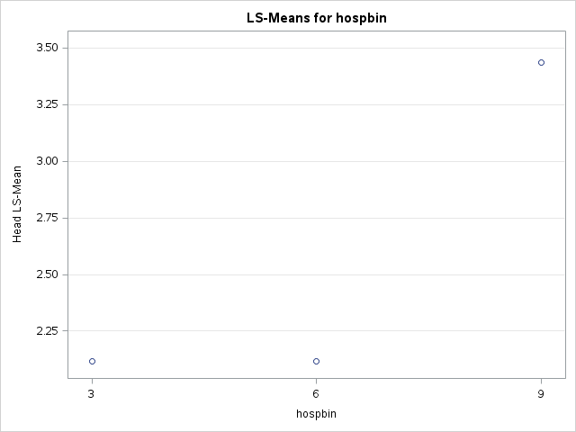

| hospbin | Body LSMEAN |
| --- | --- |
| 3 | 2.81909324 |
| 6 | 2.58785874 |
| 9 | 3.18991917 |

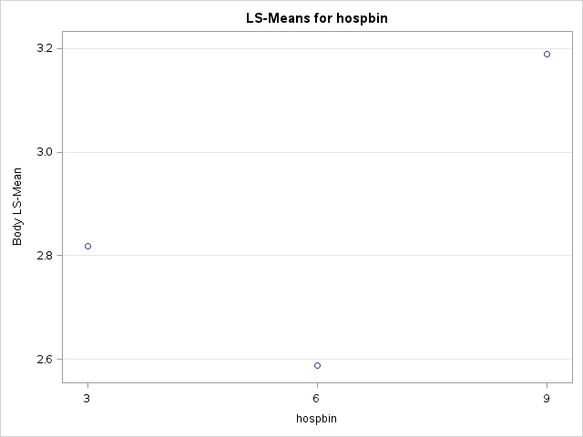

| hospbin | Tail LSMEAN |
| --- | --- |
| 3 | 2.81955772 |
| 6 | 2.41700594 |
| 9 | 3.80707425 |

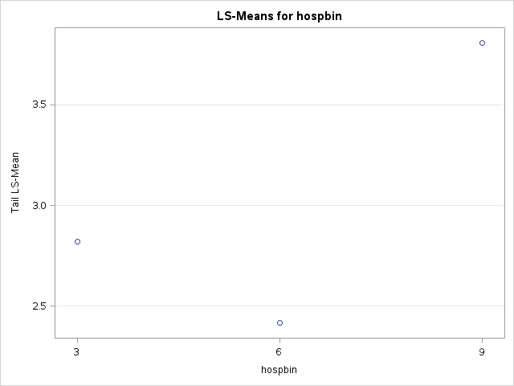

| age_group | Head LSMEAN |
| --- | --- |
| 1 | 3.13823031 |
| 2 | 2.02036300 |
| 3 | 2.51235764 |

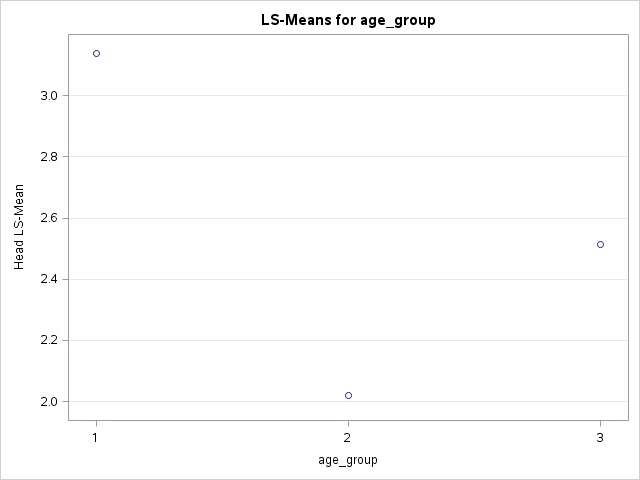

| age_group | Body LSMEAN |
| --- | --- |
| 1 | 3.08226794 |
| 2 | 2.61529383 |
| 3 | 2.89930936 |

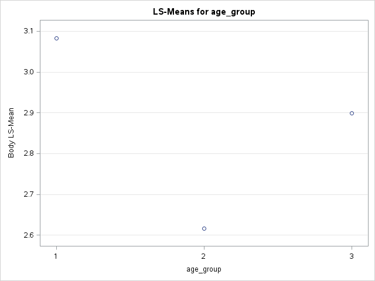

| age_group | Tail LSMEAN |
| --- | --- |
| 1 | 3.21079489 |
| 2 | 2.47398517 |
| 3 | 3.35885786 |

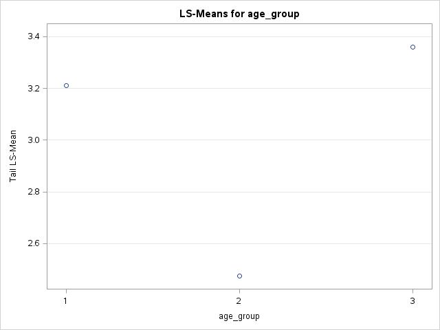

| hospbin | age_group | Head LSMEAN |
| --- | --- | --- |
| 3 | 1 | 1.62014067 |
| 3 | 2 | 3.27999250 |
| 3 | 3 | 1.45172738 |
| 6 | 1 | 2.66193775 |
| 6 | 2 | 1.10180650 |
| 6 | 3 | 2.58450429 |
| 9 | 1 | 5.13261250 |
| 9 | 2 | 1.67929000 |
| 9 | 3 | 3.50084125 |

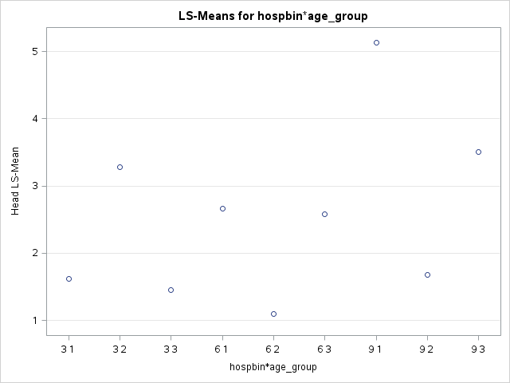

| hospbin | age_group | Body LSMEAN |
| --- | --- | --- |
| 3 | 1 | 1.78869133 |
| 3 | 2 | 5.22790350 |
| 3 | 3 | 1.44068488 |
| 6 | 1 | 3.36748250 |
| 6 | 2 | 1.00343800 |
| 6 | 3 | 3.39265571 |
| 9 | 1 | 4.09063000 |
| 9 | 2 | 1.61454000 |
| 9 | 3 | 3.86458750 |

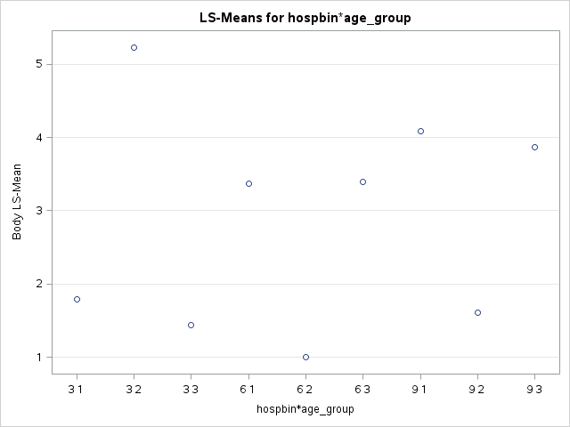

| hospbin | age_group | Tail LSMEAN |
| --- | --- | --- |
| 3 | 1 | 1.74930567 |
| 3 | 2 | 5.00996250 |
| 3 | 3 | 1.69940500 |
| 6 | 1 | 2.90622625 |
| 6 | 2 | 1.35808300 |
| 6 | 3 | 2.98670857 |
| 9 | 1 | 4.97685275 |
| 9 | 2 | 1.05391000 |
| 9 | 3 | 5.39046000 |

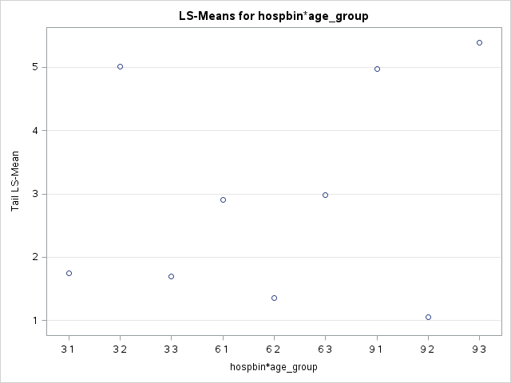

The Mixed Procedure

| Model Information |  |
| --- | --- |
| Data Set | WORK.CD68 |
| Dependent Variable | percent_cd68 |
| Covariance Structure | Unstructured |
| Subject Effect | Case(hospbin) |
| Estimation Method | REML |
| Residual Variance Method | None |
| Fixed Effects SE Method | Model-Based |
| Degrees of Freedom Method | Between-Within |

| Class Level Information Class | Class Level Information Levels | Class Level Information Values |
| --- | --- | --- |
| Case | 39 | 6003 6005 6007 6008 6011 6019 6047 6048 6057 6060 6073 6099 6104 6106 6115 6117 6126 6129 6131 6134 6140 6144 6162 6165 6172 6174 6178 6179 6187 6200 6219 6229 6230 6235 6250 6251 6254 6278 6279 |
| hospbin | 3 | 3 6 9 |
| age_group | 3 | 1 2 3 |
| sample_type2 | 3 | A B C |

| Dimensions |  |
| --- | --- |
| Covariance Parameters | 6 |
| Columns in X | 64 |
| Columns in Z | 0 |
| Subjects | 39 |
| Max Obs per Subject | 3 |

| Number of Observations |  |
| --- | --- |
| Number of Observations Read | 117 |
| Number of Observations Used | 117 |
| Number of Observations Not Used | 0 |

| Iteration History Iteration | Iteration History Evaluations | Iteration History -2 Res Log Like | Iteration History Criterion |
| --- | --- | --- | --- |
| 0 | 1 | 466.11903024 |  |
| 1 | 1 | 365.10229756 | 0.00000000 |

| Convergence criteria met. |
| --- |

| Covariance Parameter Estimates Cov Parm | Covariance Parameter Estimates Subject | Covariance Parameter Estimates Estimate |
| --- | --- | --- |
| UN(1,1) | Case(hospbin) | 5.9362 |
| UN(2,1) | Case(hospbin) | 5.2666 |
| UN(2,2) | Case(hospbin) | 6.2878 |
| UN(3,1) | Case(hospbin) | 6.6957 |
| UN(3,2) | Case(hospbin) | 6.6106 |
| UN(3,3) | Case(hospbin) | 9.1269 |

| Fit Statistics |  |
| --- | --- |
| -2 Res Log Likelihood | 365.1 |
| AIC (Smaller is Better) | 377.1 |
| AICC (Smaller is Better) | 378.1 |
| BIC (Smaller is Better) | 387.1 |

| Null Model Likelihood Ratio Test DF | Null Model Likelihood Ratio Test Chi-Square | Null Model Likelihood Ratio Test Pr > ChiSq |
| --- | --- | --- |
| 5 | 101.02 | <.0001 |

| Type 3 Tests of Fixed Effects Effect | Type 3 Tests of Fixed Effects Num DF | Type 3 Tests of Fixed Effects Den DF | Type 3 Tests of Fixed Effects F Value | Type 3 Tests of Fixed Effects Pr > F |
| --- | --- | --- | --- | --- |
| hospbin | 2 | 30 | 0.40 | 0.6768 |
| age_group | 2 | 30 | 0.15 | 0.8644 |
| hospbin*age_group | 4 | 30 | 1.08 | 0.3822 |
| sample_type2 | 2 | 30 | 1.76 | 0.1895 |
| hospbin*sample_type2 | 4 | 30 | 0.65 | 0.6347 |
| age_group*sample_typ | 4 | 30 | 0.81 | 0.5265 |
| hospbi*age_gr*sample | 8 | 30 | 1.45 | 0.2158 |

| Least Squares Means Effect | Least Squares Means sample_type2 | Least Squares Means hospbin | Least Squares Means age_group | Least Squares Means Estimate | Least Squares Means Standard Error | Least Squares Means DF | Least Squares Means t Value | Least Squares Means Pr > \|t\| | Least Squares Means Alpha | Least Squares Means Lower | Least Squares Means Upper |
| --- | --- | --- | --- | --- | --- | --- | --- | --- | --- | --- | --- |
| hospbin |  | 3 |  | 2.5853 | 0.8319 | 30 | 3.11 | 0.0041 | 0.05 | 0.8863 | 4.2843 |
| hospbin |  | 6 |  | 2.3736 | 0.8030 | 30 | 2.96 | 0.0060 | 0.05 | 0.7337 | 4.0136 |
| hospbin |  | 9 |  | 3.4782 | 0.9965 | 30 | 3.49 | 0.0015 | 0.05 | 1.4431 | 5.5133 |
| age_group |  |  | 1 | 3.1438 | 0.7758 | 30 | 4.05 | 0.0003 | 0.05 | 1.5594 | 4.7281 |
| age_group |  |  | 2 | 2.3699 | 1.2018 | 30 | 1.97 | 0.0579 | 0.05 | -0.08455 | 4.8243 |
| age_group |  |  | 3 | 2.9235 | 0.5326 | 30 | 5.49 | <.0001 | 0.05 | 1.8357 | 4.0113 |
| hospbin*age_group |  | 3 | 1 | 1.7194 | 1.4719 | 30 | 1.17 | 0.2520 | 0.05 | -1.2867 | 4.7254 |
| hospbin*age_group |  | 3 | 2 | 4.5060 | 1.8027 | 30 | 2.50 | 0.0181 | 0.05 | 0.8243 | 8.1876 |
| hospbin*age_group |  | 3 | 3 | 1.5306 | 0.9014 | 30 | 1.70 | 0.0998 | 0.05 | -0.3102 | 3.3714 |
| hospbin*age_group |  | 6 | 1 | 2.9785 | 1.2747 | 30 | 2.34 | 0.0263 | 0.05 | 0.3752 | 5.5819 |
| hospbin*age_group |  | 6 | 2 | 1.1544 | 1.8027 | 30 | 0.64 | 0.5268 | 0.05 | -2.5272 | 4.8361 |
| hospbin*age_group |  | 6 | 3 | 2.9880 | 0.9636 | 30 | 3.10 | 0.0042 | 0.05 | 1.0200 | 4.9559 |
| hospbin*age_group |  | 9 | 1 | 4.7334 | 1.2747 | 30 | 3.71 | 0.0008 | 0.05 | 2.1300 | 7.3367 |
| hospbin*age_group |  | 9 | 2 | 1.4492 | 2.5494 | 30 | 0.57 | 0.5740 | 0.05 | -3.7574 | 6.6559 |
| hospbin*age_group |  | 9 | 3 | 4.2520 | 0.9014 | 30 | 4.72 | <.0001 | 0.05 | 2.4111 | 6.0928 |
| sample_type2 | A |  |  | 2.5570 | 0.4862 | 30 | 5.26 | <.0001 | 0.05 | 1.5639 | 3.5500 |
| sample_type2 | B |  |  | 2.8656 | 0.5004 | 30 | 5.73 | <.0001 | 0.05 | 1.8436 | 3.8877 |
| sample_type2 | C |  |  | 3.0145 | 0.6029 | 30 | 5.00 | <.0001 | 0.05 | 1.7832 | 4.2459 |
| hospbin*sample_type2 | A | 3 |  | 2.1173 | 0.7950 | 30 | 2.66 | 0.0123 | 0.05 | 0.4936 | 3.7410 |
| hospbin*sample_type2 | B | 3 |  | 2.8191 | 0.8182 | 30 | 3.45 | 0.0017 | 0.05 | 1.1480 | 4.4902 |
| hospbin*sample_type2 | C | 3 |  | 2.8196 | 0.9858 | 30 | 2.86 | 0.0076 | 0.05 | 0.8062 | 4.8329 |
| hospbin*sample_type2 | A | 6 |  | 2.1161 | 0.7674 | 30 | 2.76 | 0.0098 | 0.05 | 0.5488 | 3.6833 |
| hospbin*sample_type2 | B | 6 |  | 2.5879 | 0.7898 | 30 | 3.28 | 0.0027 | 0.05 | 0.9749 | 4.2008 |
| hospbin*sample_type2 | C | 6 |  | 2.4170 | 0.9516 | 30 | 2.54 | 0.0165 | 0.05 | 0.4737 | 4.3603 |
| hospbin*sample_type2 | A | 9 |  | 3.4376 | 0.9523 | 30 | 3.61 | 0.0011 | 0.05 | 1.4927 | 5.3825 |
| hospbin*sample_type2 | B | 9 |  | 3.1899 | 0.9801 | 30 | 3.25 | 0.0028 | 0.05 | 1.1882 | 5.1916 |
| hospbin*sample_type2 | C | 9 |  | 3.8071 | 1.1808 | 30 | 3.22 | 0.0030 | 0.05 | 1.3955 | 6.2187 |
| age_group*sample_typ | A |  | 1 | 3.1382 | 0.7414 | 30 | 4.23 | 0.0002 | 0.05 | 1.6241 | 4.6523 |
| age_group*sample_typ | B |  | 1 | 3.0823 | 0.7630 | 30 | 4.04 | 0.0003 | 0.05 | 1.5240 | 4.6406 |
| age_group*sample_typ | C |  | 1 | 3.2108 | 0.9193 | 30 | 3.49 | 0.0015 | 0.05 | 1.3334 | 5.0882 |
| age_group*sample_typ | A |  | 2 | 2.0204 | 1.1485 | 30 | 1.76 | 0.0888 | 0.05 | -0.3253 | 4.3660 |
| age_group*sample_typ | B |  | 2 | 2.6153 | 1.1821 | 30 | 2.21 | 0.0347 | 0.05 | 0.2012 | 5.0294 |
| age_group*sample_typ | C |  | 2 | 2.4740 | 1.4242 | 30 | 1.74 | 0.0926 | 0.05 | -0.4345 | 5.3825 |
| age_group*sample_typ | A |  | 3 | 2.5124 | 0.5090 | 30 | 4.94 | <.0001 | 0.05 | 1.4728 | 3.5519 |
| age_group*sample_typ | B |  | 3 | 2.8993 | 0.5239 | 30 | 5.53 | <.0001 | 0.05 | 1.8294 | 3.9692 |
| age_group*sample_typ | C |  | 3 | 3.3589 | 0.6312 | 30 | 5.32 | <.0001 | 0.05 | 2.0698 | 4.6479 |
| hospbi*age_gr*sample | A | 3 | 1 | 1.6201 | 1.4067 | 30 | 1.15 | 0.2585 | 0.05 | -1.2527 | 4.4929 |
| hospbi*age_gr*sample | B | 3 | 1 | 1.7887 | 1.4477 | 30 | 1.24 | 0.2262 | 0.05 | -1.1680 | 4.7454 |
| hospbi*age_gr*sample | C | 3 | 1 | 1.7493 | 1.7442 | 30 | 1.00 | 0.3239 | 0.05 | -1.8129 | 5.3115 |
| hospbi*age_gr*sample | A | 3 | 2 | 3.2800 | 1.7228 | 30 | 1.90 | 0.0666 | 0.05 | -0.2385 | 6.7984 |
| hospbi*age_gr*sample | B | 3 | 2 | 5.2279 | 1.7731 | 30 | 2.95 | 0.0061 | 0.05 | 1.6067 | 8.8491 |
| hospbi*age_gr*sample | C | 3 | 2 | 5.0100 | 2.1362 | 30 | 2.35 | 0.0258 | 0.05 | 0.6472 | 9.3727 |
| hospbi*age_gr*sample | A | 3 | 3 | 1.4517 | 0.8614 | 30 | 1.69 | 0.1023 | 0.05 | -0.3075 | 3.2110 |
| hospbi*age_gr*sample | B | 3 | 3 | 1.4407 | 0.8866 | 30 | 1.63 | 0.1146 | 0.05 | -0.3699 | 3.2513 |
| hospbi*age_gr*sample | C | 3 | 3 | 1.6994 | 1.0681 | 30 | 1.59 | 0.1221 | 0.05 | -0.4820 | 3.8808 |
| hospbi*age_gr*sample | A | 6 | 1 | 2.6619 | 1.2182 | 30 | 2.19 | 0.0368 | 0.05 | 0.1740 | 5.1499 |
| hospbi*age_gr*sample | B | 6 | 1 | 3.3675 | 1.2538 | 30 | 2.69 | 0.0117 | 0.05 | 0.8069 | 5.9280 |
| hospbi*age_gr*sample | C | 6 | 1 | 2.9062 | 1.5105 | 30 | 1.92 | 0.0639 | 0.05 | -0.1787 | 5.9912 |
| hospbi*age_gr*sample | A | 6 | 2 | 1.1018 | 1.7228 | 30 | 0.64 | 0.5273 | 0.05 | -2.4166 | 4.6203 |
| hospbi*age_gr*sample | B | 6 | 2 | 1.0034 | 1.7731 | 30 | 0.57 | 0.5757 | 0.05 | -2.6177 | 4.6246 |
| hospbi*age_gr*sample | C | 6 | 2 | 1.3581 | 2.1362 | 30 | 0.64 | 0.5298 | 0.05 | -3.0047 | 5.7208 |
| hospbi*age_gr*sample | A | 6 | 3 | 2.5845 | 0.9209 | 30 | 2.81 | 0.0087 | 0.05 | 0.7038 | 4.4652 |
| hospbi*age_gr*sample | B | 6 | 3 | 3.3927 | 0.9478 | 30 | 3.58 | 0.0012 | 0.05 | 1.4571 | 5.3282 |
| hospbi*age_gr*sample | C | 6 | 3 | 2.9867 | 1.1419 | 30 | 2.62 | 0.0138 | 0.05 | 0.6547 | 5.3187 |
| hospbi*age_gr*sample | A | 9 | 1 | 5.1326 | 1.2182 | 30 | 4.21 | 0.0002 | 0.05 | 2.6447 | 7.6205 |
| hospbi*age_gr*sample | B | 9 | 1 | 4.0906 | 1.2538 | 30 | 3.26 | 0.0028 | 0.05 | 1.5301 | 6.6512 |
| hospbi*age_gr*sample | C | 9 | 1 | 4.9769 | 1.5105 | 30 | 3.29 | 0.0025 | 0.05 | 1.8919 | 8.0618 |
| hospbi*age_gr*sample | A | 9 | 2 | 1.6793 | 2.4364 | 30 | 0.69 | 0.4960 | 0.05 | -3.2966 | 6.6551 |
| hospbi*age_gr*sample | B | 9 | 2 | 1.6145 | 2.5075 | 30 | 0.64 | 0.5246 | 0.05 | -3.5065 | 6.7356 |
| hospbi*age_gr*sample | C | 9 | 2 | 1.0539 | 3.0211 | 30 | 0.35 | 0.7296 | 0.05 | -5.1160 | 7.2238 |
| hospbi*age_gr*sample | A | 9 | 3 | 3.5008 | 0.8614 | 30 | 4.06 | 0.0003 | 0.05 | 1.7416 | 5.2601 |
| hospbi*age_gr*sample | B | 9 | 3 | 3.8646 | 0.8866 | 30 | 4.36 | 0.0001 | 0.05 | 2.0540 | 5.6752 |
| hospbi*age_gr*sample | C | 9 | 3 | 5.3905 | 1.0681 | 30 | 5.05 | <.0001 | 0.05 | 3.2091 | 7.5718 |

| Differences of Least Squares Means Effect | Differences of Least Squares Means sample_type2 | Differences of Least Squares Means hospbin | Differences of Least Squares Means age_group | Differences of Least Squares Means _sample_type2 | Differences of Least Squares Means hospbin | Differences of Least Squares Means _age_group | Differences of Least Squares Means Estimate | Differences of Least Squares Means Standard Error | Differences of Least Squares Means DF | Differences of Least Squares Means t Value | Differences of Least Squares Means Pr > \|t\| | Differences of Least Squares Means Adjustment | Differences of Least Squares Means Adj P | Differences of Least Squares Means Alpha | Differences of Least Squares Means Lower | Differences of Least Squares Means Upper | Differences of Least Squares Means Adj Lower | Differences of Least Squares Means Adj Upper |
| --- | --- | --- | --- | --- | --- | --- | --- | --- | --- | --- | --- | --- | --- | --- | --- | --- | --- | --- |
| hospbin |  | 3 |  |  | 6 |  | 0.2117 | 1.1562 | 30 | 0.18 | 0.8560 | Tukey-Kramer | 0.9817 | 0.05 | -2.1497 | 2.5730 | -2.6388 | 3.0621 |
| hospbin |  | 3 |  |  | 9 |  | -0.8929 | 1.2981 | 30 | -0.69 | 0.4968 | Tukey-Kramer | 0.7723 | 0.05 | -3.5440 | 1.7582 | -4.0930 | 2.3073 |
| hospbin |  | 6 |  |  | 9 |  | -1.1045 | 1.2798 | 30 | -0.86 | 0.3949 | Tukey-Kramer | 0.6673 | 0.05 | -3.7182 | 1.5091 | -4.2595 | 2.0504 |
| age_group |  |  | 1 |  |  | 2 | 0.7739 | 1.4304 | 30 | 0.54 | 0.5925 | Tukey-Kramer | 0.8518 | 0.05 | -2.1475 | 3.6952 | -2.7525 | 4.3003 |
| age_group |  |  | 1 |  |  | 3 | 0.2203 | 0.9410 | 30 | 0.23 | 0.8165 | Tukey-Kramer | 0.9703 | 0.05 | -1.7016 | 2.1421 | -2.0996 | 2.5401 |
| age_group |  |  | 2 |  |  | 3 | -0.5536 | 1.3146 | 30 | -0.42 | 0.6766 | Tukey-Kramer | 0.9072 | 0.05 | -3.2383 | 2.1311 | -3.7944 | 2.6871 |
| hospbin*age_group |  | 3 | 1 |  | 3 | 2 | -2.7866 | 2.3273 | 30 | -1.20 | 0.2406 | Tukey-Kramer | 0.9509 | 0.05 | -7.5396 | 1.9664 | -10.5540 | 4.9808 |
| hospbin*age_group |  | 3 | 1 |  | 3 | 3 | 0.1888 | 1.7260 | 30 | 0.11 | 0.9136 | Tukey-Kramer | 1.0000 | 0.05 | -3.3361 | 3.7137 | -5.5717 | 5.9492 |
| hospbin*age_group |  | 3 | 1 |  | 6 | 1 | -1.2592 | 1.9472 | 30 | -0.65 | 0.5228 | Tukey-Kramer | 0.9991 | 0.05 | -5.2358 | 2.7175 | -7.7578 | 5.2395 |
| hospbin*age_group |  | 3 | 1 |  | 6 | 2 | 0.5649 | 2.3273 | 30 | 0.24 | 0.8099 | Tukey-Kramer | 1.0000 | 0.05 | -4.1881 | 5.3179 | -7.2024 | 8.3323 |
| hospbin*age_group |  | 3 | 1 |  | 6 | 3 | -1.2686 | 1.7593 | 30 | -0.72 | 0.4764 | Tukey-Kramer | 0.9981 | 0.05 | -4.8615 | 2.3243 | -7.1402 | 4.6030 |
| hospbin*age_group |  | 3 | 1 |  | 9 | 1 | -3.0140 | 1.9472 | 30 | -1.55 | 0.1321 | Tukey-Kramer | 0.8240 | 0.05 | -6.9906 | 0.9627 | -9.5126 | 3.4847 |
| hospbin*age_group |  | 3 | 1 |  | 9 | 2 | 0.2701 | 2.9438 | 30 | 0.09 | 0.9275 | Tukey-Kramer | 1.0000 | 0.05 | -5.7420 | 6.2822 | -9.5549 | 10.0952 |
| hospbin*age_group |  | 3 | 1 |  | 9 | 3 | -2.5326 | 1.7260 | 30 | -1.47 | 0.1527 | Tukey-Kramer | 0.8614 | 0.05 | -6.0575 | 0.9923 | -8.2930 | 3.2279 |
| hospbin*age_group |  | 3 | 2 |  | 3 | 3 | 2.9753 | 2.0155 | 30 | 1.48 | 0.1503 | Tukey-Kramer | 0.8575 | 0.05 | -1.1409 | 7.0916 | -3.7514 | 9.7021 |
| hospbin*age_group |  | 3 | 2 |  | 6 | 1 | 1.5274 | 2.2079 | 30 | 0.69 | 0.4944 | Tukey-Kramer | 0.9985 | 0.05 | -2.9817 | 6.0365 | -5.8414 | 8.8962 |
| hospbin*age_group |  | 3 | 2 |  | 6 | 2 | 3.3515 | 2.5494 | 30 | 1.31 | 0.1986 | Tukey-Kramer | 0.9190 | 0.05 | -1.8551 | 8.5582 | -5.1572 | 11.8603 |
| hospbin*age_group |  | 3 | 2 |  | 6 | 3 | 1.5180 | 2.0441 | 30 | 0.74 | 0.4635 | Tukey-Kramer | 0.9976 | 0.05 | -2.6566 | 5.6926 | -5.3042 | 8.3402 |
| hospbin*age_group |  | 3 | 2 |  | 9 | 1 | -0.2274 | 2.2079 | 30 | -0.10 | 0.9186 | Tukey-Kramer | 1.0000 | 0.05 | -4.7365 | 4.2817 | -7.5962 | 7.1414 |
| hospbin*age_group |  | 3 | 2 |  | 9 | 2 | 3.0567 | 3.1224 | 30 | 0.98 | 0.3354 | Tukey-Kramer | 0.9851 | 0.05 | -3.3201 | 9.4335 | -7.3643 | 13.4777 |
| hospbin*age_group |  | 3 | 2 |  | 9 | 3 | 0.2540 | 2.0155 | 30 | 0.13 | 0.9006 | Tukey-Kramer | 1.0000 | 0.05 | -3.8622 | 4.3702 | -6.4728 | 6.9807 |
| hospbin*age_group |  | 3 | 3 |  | 6 | 1 | -1.4479 | 1.5612 | 30 | -0.93 | 0.3611 | Tukey-Kramer | 0.9894 | 0.05 | -4.6363 | 1.7405 | -6.6585 | 3.7626 |
| hospbin*age_group |  | 3 | 3 |  | 6 | 2 | 0.3762 | 2.0155 | 30 | 0.19 | 0.8532 | Tukey-Kramer | 1.0000 | 0.05 | -3.7400 | 4.4924 | -6.3506 | 7.1029 |
| hospbin*age_group |  | 3 | 3 |  | 6 | 3 | -1.4574 | 1.3195 | 30 | -1.10 | 0.2782 | Tukey-Kramer | 0.9690 | 0.05 | -4.1520 | 1.2373 | -5.8610 | 2.9463 |
| hospbin*age_group |  | 3 | 3 |  | 9 | 1 | -3.2028 | 1.5612 | 30 | -2.05 | 0.0490 | Tukey-Kramer | 0.5223 | 0.05 | -6.3912 | -0.01436 | -8.4133 | 2.0078 |
| hospbin*age_group |  | 3 | 3 |  | 9 | 2 | 0.08136 | 2.7041 | 30 | 0.03 | 0.9762 | Tukey-Kramer | 1.0000 | 0.05 | -5.4411 | 5.6038 | -8.9435 | 9.1062 |
| hospbin*age_group |  | 3 | 3 |  | 9 | 3 | -2.7214 | 1.2747 | 30 | -2.13 | 0.0411 | Tukey-Kramer | 0.4703 | 0.05 | -5.3247 | -0.1180 | -6.9757 | 1.5330 |
| hospbin*age_group |  | 6 | 1 |  | 6 | 2 | 1.8241 | 2.2079 | 30 | 0.83 | 0.4152 | Tukey-Kramer | 0.9950 | 0.05 | -2.6850 | 6.3332 | -5.5447 | 9.1929 |
| hospbin*age_group |  | 6 | 1 |  | 6 | 3 | -0.00941 | 1.5979 | 30 | -0.01 | 0.9953 | Tukey-Kramer | 1.0000 | 0.05 | -3.2728 | 3.2540 | -5.3425 | 5.3237 |
| hospbin*age_group |  | 6 | 1 |  | 9 | 1 | -1.7548 | 1.8027 | 30 | -0.97 | 0.3381 | Tukey-Kramer | 0.9856 | 0.05 | -5.4365 | 1.9268 | -7.7714 | 4.2618 |

[output cut: 438 more lines]

```sas
PROC glm data=cd68_no_insulin;
     class hospbin age_group;
     model Head Body Tail= hospbin|age_group/nouni;
     repeated sample_type2 / short printe;
     lsmeans hospbin|age_group /out=cd68_lsmeans (drop=stderr);
run;
quit;

PROC mixed data=cd68;
     class case hospbin age_group sample_type2;
     model percent_cd68=hospbin|age_group|sample_type2;
     repeated sample_type2/ subject=case(hospbin) type=un;
     lsmeans hospbin|age_group|sample_type2 /adjust=tukey cl pdiff alpha=0.05;
run;
```

Data for supplemental table 2 and Figure 1

```sas
/*ls means values by head body and tail*/

DATA cd68_lsmeans1 (drop=age_group);
     set cd68_lsmeans;
     if age_group^="" then delete;
     stain="CD68           ";
     rename _NAME_=pancreas_region;
run;

PROC print data=cd68_lsmeans1;
run;

/*grand mean values*/

PROC means data=cd68_lsmeans1 mean;
     var lsmean;
     class hospbin;
     output out=cd68_grandmean;
run;

DATA cd68_grandmean (drop=_type_ _freq_ _stat_);
     set cd68_grandmean;
     if _stat_^="MEAN" then delete;
     if hospbin="" then delete;
     pancreas_region="Overall";
     stain="CD68           ";
run;

/*combine files into 1*/

DATA CD68_fig1;
     set CD68_lsmeans1 CD68_grandmean;
run;

PROC print data=CD68_fig1;
run;
```

| Obs | pancreas_region | hospbin | LSMEAN | stain |
| --- | --- | --- | --- | --- |
| 1 | Head | 3 | 2.11729 | CD68 |
| 2 | Head | 6 | 2.11608 | CD68 |
| 3 | Head | 9 | 3.43758 | CD68 |
| 4 | Body | 3 | 2.81909 | CD68 |
| 5 | Body | 6 | 2.58786 | CD68 |
| 6 | Body | 9 | 3.18992 | CD68 |
| 7 | Tail | 3 | 2.81956 | CD68 |
| 8 | Tail | 6 | 2.41701 | CD68 |
| 9 | Tail | 9 | 3.80707 | CD68 |

The MEANS Procedure

| Analysis Variable : LSMEAN hospbin | Analysis Variable : LSMEAN N Obs | Analysis Variable : LSMEAN Mean |
| --- | --- | --- |
| 3 | 3 | 2.5853126 |
| 6 | 3 | 2.3736492 |
| 9 | 3 | 3.4781916 |

| Obs | pancreas_region | hospbin | LSMEAN | stain |
| --- | --- | --- | --- | --- |
| 1 | Head | 3 | 2.11729 | CD68 |
| 2 | Head | 6 | 2.11608 | CD68 |
| 3 | Head | 9 | 3.43758 | CD68 |
| 4 | Body | 3 | 2.81909 | CD68 |
| 5 | Body | 6 | 2.58786 | CD68 |
| 6 | Body | 9 | 3.18992 | CD68 |
| 7 | Tail | 3 | 2.81956 | CD68 |
| 8 | Tail | 6 | 2.41701 | CD68 |
| 9 | Tail | 9 | 3.80707 | CD68 |
| 10 | Overall | 3 | 2.58531 | CD68 |
| 11 | Overall | 6 | 2.37365 | CD68 |
| 12 | Overall | 9 | 3.47819 | CD68 |

### Insulin dataset

statistical analysis model

The GLM Procedure

| Class Level Information Class | Class Level Information Levels | Class Level Information Values |
| --- | --- | --- |
| hospbin | 3 | 3 6 9 |
| age_group | 3 | 1 2 3 |

| Number of Observations Read | 39 |
| --- | --- |
| Number of Observations Used | 39 |

The GLM Procedure

Repeated Measures Analysis of Variance

| Repeated Measures Level Information Dependent Variable | Repeated Measures Level Information Head | Repeated Measures Level Information Body | Repeated Measures Level Information Tail |
| --- | --- | --- | --- |
| Level of sample_type2 | 1 | 2 | 3 |

| Partial Correlation Coefficients from the Error SSCP Matrix / Prob > \|r\| DF = 30 | Partial Correlation Coefficients from the Error SSCP Matrix / Prob > \|r\| Head | Partial Correlation Coefficients from the Error SSCP Matrix / Prob > \|r\| Body | Partial Correlation Coefficients from the Error SSCP Matrix / Prob > \|r\| Tail |
| --- | --- | --- | --- |
| Head | 1.000000 | 0.949948 <.0001 | 0.881226 <.0001 |
| Body | 0.949948 <.0001 | 1.000000 | 0.939152 <.0001 |
| Tail | 0.881226 <.0001 | 0.939152 <.0001 | 1.000000 |

| E = Error SSCP Matrix sample_type2_N represents the contrast between the nth level of sample_type2 and the last | E = Error SSCP Matrix sample_type2_N represents the contrast between the nth level of sample_type2 and the last sample_type2_1 | E = Error SSCP Matrix sample_type2_N represents the contrast between the nth level of sample_type2 and the last sample_type2_2 |
| --- | --- | --- |
| sample_type2_1 | 45.188 | 18.763 |
| sample_type2_2 | 18.763 | 18.114 |

| Partial Correlation Coefficients from the Error SSCP Matrix of the Variables Defined by the Specified Transformation / Prob > \|r\| DF = 30 | Partial Correlation Coefficients from the Error SSCP Matrix of the Variables Defined by the Specified Transformation / Prob > \|r\| sample_type2_1 | Partial Correlation Coefficients from the Error SSCP Matrix of the Variables Defined by the Specified Transformation / Prob > \|r\| sample_type2_2 |
| --- | --- | --- |
| sample_type2_1 | 1.000000 | 0.655805 <.0001 |
| sample_type2_2 | 0.655805 <.0001 | 1.000000 |

| Sphericity Tests Variables | Sphericity Tests DF | Sphericity Tests Mauchly's Criterion | Sphericity Tests Chi-Square | Sphericity Tests Pr > ChiSq |
| --- | --- | --- | --- | --- |
| Transformed Variates | 2 | 0.465673 | 22.163876 | <.0001 |
| Orthogonal Components | 2 | 0.7054901 | 10.117014 | 0.0064 |

| MANOVA Test Criteria and Exact F Statistics for the Hypothesis of no sample_type2 Effect H = Type III SSCP Matrix for sample_type2 E = Error SSCP Matrix S=1 M=0 N=13.5 Statistic | MANOVA Test Criteria and Exact F Statistics for the Hypothesis of no sample_type2 Effect H = Type III SSCP Matrix for sample_type2 E = Error SSCP Matrix S=1 M=0 N=13.5 Value | MANOVA Test Criteria and Exact F Statistics for the Hypothesis of no sample_type2 Effect H = Type III SSCP Matrix for sample_type2 E = Error SSCP Matrix S=1 M=0 N=13.5 F Value | MANOVA Test Criteria and Exact F Statistics for the Hypothesis of no sample_type2 Effect H = Type III SSCP Matrix for sample_type2 E = Error SSCP Matrix S=1 M=0 N=13.5 Num DF | MANOVA Test Criteria and Exact F Statistics for the Hypothesis of no sample_type2 Effect H = Type III SSCP Matrix for sample_type2 E = Error SSCP Matrix S=1 M=0 N=13.5 Den DF | MANOVA Test Criteria and Exact F Statistics for the Hypothesis of no sample_type2 Effect H = Type III SSCP Matrix for sample_type2 E = Error SSCP Matrix S=1 M=0 N=13.5 Pr > F |
| --- | --- | --- | --- | --- | --- |
| Wilks' Lambda | 0.52375843 | 13.18 | 2 | 29 | <.0001 |
| Pillai's Trace | 0.47624157 | 13.18 | 2 | 29 | <.0001 |
| Hotelling-Lawley Trace | 0.90927713 | 13.18 | 2 | 29 | <.0001 |
| Roy's Greatest Root | 0.90927713 | 13.18 | 2 | 29 | <.0001 |

| MANOVA Test Criteria and F Approximations for the Hypothesis of no sample_type2*hospbin Effect H = Type III SSCP Matrix for sample_type2*hospbin E = Error SSCP Matrix S=2 M=-0.5 N=13.5 Statistic | MANOVA Test Criteria and F Approximations for the Hypothesis of no sample_type2*hospbin Effect H = Type III SSCP Matrix for sample_type2*hospbin E = Error SSCP Matrix S=2 M=-0.5 N=13.5 Value | MANOVA Test Criteria and F Approximations for the Hypothesis of no sample_type2*hospbin Effect H = Type III SSCP Matrix for sample_type2*hospbin E = Error SSCP Matrix S=2 M=-0.5 N=13.5 F Value | MANOVA Test Criteria and F Approximations for the Hypothesis of no sample_type2*hospbin Effect H = Type III SSCP Matrix for sample_type2*hospbin E = Error SSCP Matrix S=2 M=-0.5 N=13.5 Num DF | MANOVA Test Criteria and F Approximations for the Hypothesis of no sample_type2*hospbin Effect H = Type III SSCP Matrix for sample_type2*hospbin E = Error SSCP Matrix S=2 M=-0.5 N=13.5 Den DF | MANOVA Test Criteria and F Approximations for the Hypothesis of no sample_type2*hospbin Effect H = Type III SSCP Matrix for sample_type2*hospbin E = Error SSCP Matrix S=2 M=-0.5 N=13.5 Pr > F |
| --- | --- | --- | --- | --- | --- |
| Wilks' Lambda | 0.91606221 | 0.65 | 4 | 58 | 0.6293 |
| Pillai's Trace | 0.08552742 | 0.67 | 4 | 60 | 0.6153 |
| Hotelling-Lawley Trace | 0.08989364 | 0.64 | 4 | 33.787 | 0.6343 |
| Roy's Greatest Root | 0.06182692 | 0.93 | 2 | 30 | 0.4066 |

NOTE: F Statistic for Roy's Greatest Root is an upper bound.  
NOTE: F Statistic for Wilks' Lambda is exact.

| MANOVA Test Criteria and F Approximations for the Hypothesis of no sample_type2*age_group Effect H = Type III SSCP Matrix for sample_type2*age_group E = Error SSCP Matrix S=2 M=-0.5 N=13.5 Statistic | MANOVA Test Criteria and F Approximations for the Hypothesis of no sample_type2*age_group Effect H = Type III SSCP Matrix for sample_type2*age_group E = Error SSCP Matrix S=2 M=-0.5 N=13.5 Value | MANOVA Test Criteria and F Approximations for the Hypothesis of no sample_type2*age_group Effect H = Type III SSCP Matrix for sample_type2*age_group E = Error SSCP Matrix S=2 M=-0.5 N=13.5 F Value | MANOVA Test Criteria and F Approximations for the Hypothesis of no sample_type2*age_group Effect H = Type III SSCP Matrix for sample_type2*age_group E = Error SSCP Matrix S=2 M=-0.5 N=13.5 Num DF | MANOVA Test Criteria and F Approximations for the Hypothesis of no sample_type2*age_group Effect H = Type III SSCP Matrix for sample_type2*age_group E = Error SSCP Matrix S=2 M=-0.5 N=13.5 Den DF | MANOVA Test Criteria and F Approximations for the Hypothesis of no sample_type2*age_group Effect H = Type III SSCP Matrix for sample_type2*age_group E = Error SSCP Matrix S=2 M=-0.5 N=13.5 Pr > F |
| --- | --- | --- | --- | --- | --- |
| Wilks' Lambda | 0.73333544 | 2.43 | 4 | 58 | 0.0575 |
| Pillai's Trace | 0.26679863 | 2.31 | 4 | 60 | 0.0682 |
| Hotelling-Lawley Trace | 0.36344961 | 2.61 | 4 | 33.787 | 0.0529 |
| Roy's Greatest Root | 0.36294587 | 5.44 | 2 | 30 | 0.0096 |

NOTE: F Statistic for Roy's Greatest Root is an upper bound.  
NOTE: F Statistic for Wilks' Lambda is exact.

| MANOVA Test Criteria and F Approximations for the Hypothesis of no sample_type2*hospbin*age_group Effect H = Type III SSCP Matrix for sample_type2*hospbin*age_group E = Error SSCP Matrix S=2 M=0.5 N=1… Statistic | MANOVA Test Criteria and F Approximations for the Hypothesis of no sample_type2*hospbin*age_group Effect H = Type III SSCP Matrix for sample_type2*hospbin*age_group E = Error SSCP Matrix S=2 M=0.5 N=1… Value | MANOVA Test Criteria and F Approximations for the Hypothesis of no sample_type2*hospbin*age_group Effect H = Type III SSCP Matrix for sample_type2*hospbin*age_group E = Error SSCP Matrix S=2 M=0.5 N=1… F Value | MANOVA Test Criteria and F Approximations for the Hypothesis of no sample_type2*hospbin*age_group Effect H = Type III SSCP Matrix for sample_type2*hospbin*age_group E = Error SSCP Matrix S=2 M=0.5 N=1… Num DF | MANOVA Test Criteria and F Approximations for the Hypothesis of no sample_type2*hospbin*age_group Effect H = Type III SSCP Matrix for sample_type2*hospbin*age_group E = Error SSCP Matrix S=2 M=0.5 N=1… Den DF | MANOVA Test Criteria and F Approximations for the Hypothesis of no sample_type2*hospbin*age_group Effect H = Type III SSCP Matrix for sample_type2*hospbin*age_group E = Error SSCP Matrix S=2 M=0.5 N=1… Pr > F |
| --- | --- | --- | --- | --- | --- |
| Wilks' Lambda | 0.77474650 | 0.99 | 8 | 58 | 0.4558 |
| Pillai's Trace | 0.22961082 | 0.97 | 8 | 60 | 0.4659 |
| Hotelling-Lawley Trace | 0.28512058 | 1.01 | 8 | 39.176 | 0.4416 |
| Roy's Greatest Root | 0.26380073 | 1.98 | 4 | 30 | 0.1233 |

NOTE: F Statistic for Roy's Greatest Root is an upper bound.  
NOTE: F Statistic for Wilks' Lambda is exact.

The GLM Procedure

Repeated Measures Analysis of Variance

Tests of Hypotheses for Between Subjects Effects

| Source | DF | Type III SS | Mean Square | F Value | Pr > F |
| --- | --- | --- | --- | --- | --- |
| hospbin | 2 | 14.4592667 | 7.2296333 | 0.49 | 0.6193 |
| age_group | 2 | 261.7807267 | 130.8903633 | 8.81 | 0.0010 |
| hospbin*age_group | 4 | 70.2225689 | 17.5556422 | 1.18 | 0.3386 |
| Error | 30 | 445.4928129 | 14.8497604 |  |  |

The GLM Procedure

Repeated Measures Analysis of Variance

Univariate Tests of Hypotheses for Within Subject Effects

| Source | DF | Type III SS | Mean Square | F Value | Pr > F | Adj Pr > F G - G | Adj Pr > F H-F-L |
| --- | --- | --- | --- | --- | --- | --- | --- |
| sample_type2 | 2 | 6.54906638 | 3.27453319 | 6.62 | 0.0025 | 0.0057 | 0.0051 |
| sample_type2*hospbin | 4 | 1.58133910 | 0.39533478 | 0.80 | 0.5307 | 0.5041 | 0.5085 |
| sample_type2*age_group | 4 | 4.73081484 | 1.18270371 | 2.39 | 0.0607 | 0.0791 | 0.0760 |
| sample_type2*hospbin*age_group | 8 | 3.46848879 | 0.43356110 | 0.88 | 0.5417 | 0.5222 | 0.5255 |
| Error(sample_type2) | 60 | 29.69284008 | 0.49488067 |  |  |  |  |

| Greenhouse-Geisser Epsilon | 0.7725 |
| --- | --- |
| Huynh-Feldt-Lecoutre Epsilon | 0.8064 |

The GLM Procedure

Least Squares Means

| hospbin | Head LSMEAN |
| --- | --- |
| 3 | 3.67605328 |
| 6 | 2.59538527 |
| 9 | 2.25901072 |

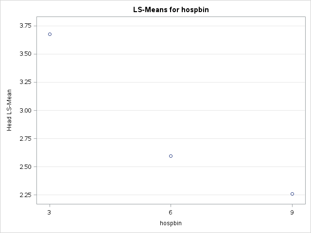

| hospbin | Body LSMEAN |
| --- | --- |
| 3 | 2.97310362 |
| 6 | 2.22844238 |
| 9 | 2.07232736 |

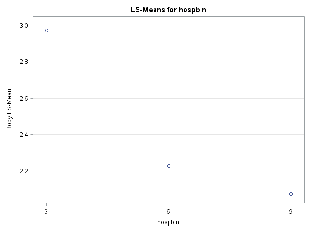

| hospbin | Tail LSMEAN |
| --- | --- |
| 3 | 3.54317333 |
| 6 | 3.19100765 |
| 9 | 2.69676590 |

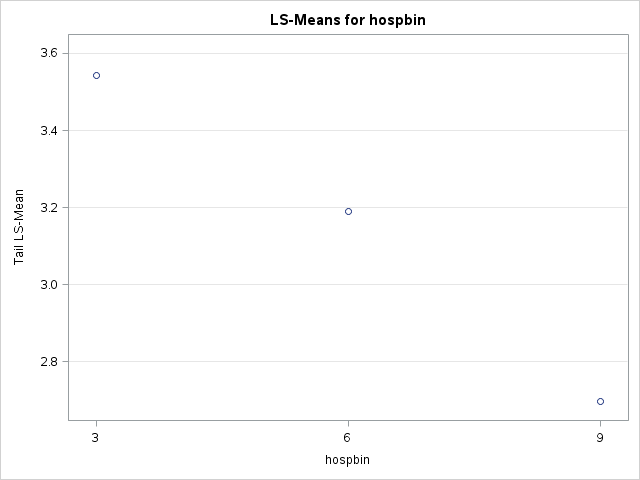

| age_group | Head LSMEAN |
| --- | --- |
| 1 | 5.29526769 |
| 2 | 2.00287461 |
| 3 | 1.23230698 |

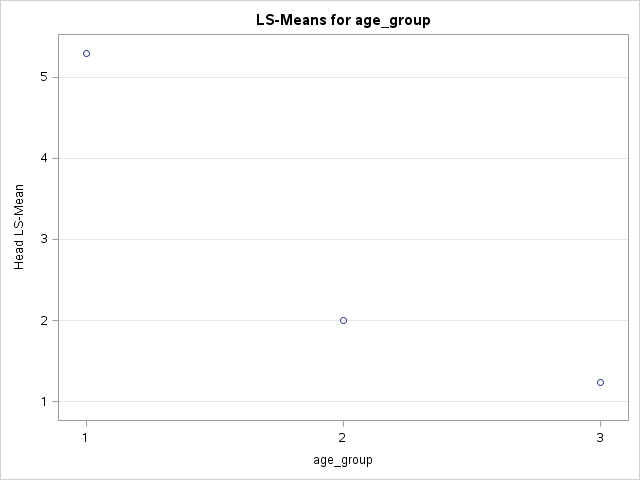

| age_group | Body LSMEAN |
| --- | --- |
| 1 | 4.27700002 |
| 2 | 1.70135672 |
| 3 | 1.29551662 |

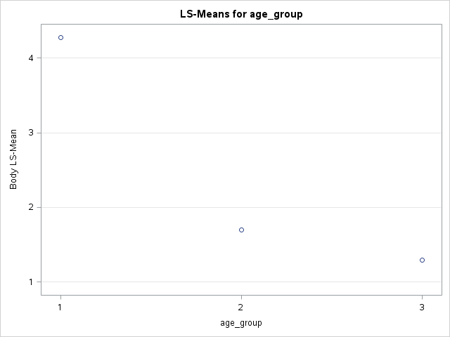

| age_group | Tail LSMEAN |
| --- | --- |
| 1 | 5.14813111 |
| 2 | 2.36051844 |
| 3 | 1.92229733 |

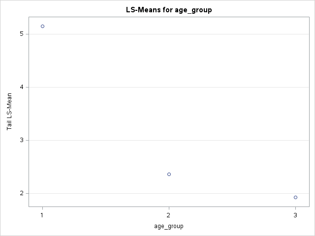

| hospbin | age_group | Head LSMEAN |
| --- | --- | --- |
| 3 | 1 | 8.15237222 |
| 3 | 2 | 1.57745333 |
| 3 | 3 | 1.29833429 |
| 6 | 1 | 4.95603750 |
| 6 | 2 | 1.65544717 |
| 6 | 3 | 1.17467114 |
| 9 | 1 | 2.77739333 |
| 9 | 2 | 2.77572333 |
| 9 | 3 | 1.22391550 |

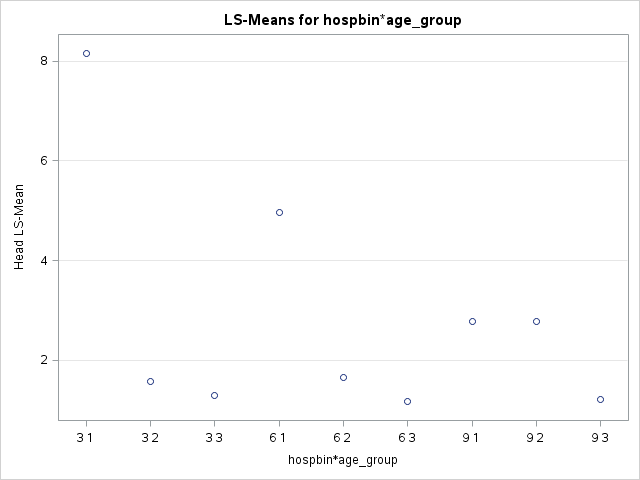

| hospbin | age_group | Body LSMEAN |
| --- | --- | --- |
| 3 | 1 | 6.01730289 |
| 3 | 2 | 1.51584667 |
| 3 | 3 | 1.38616129 |
| 6 | 1 | 4.23163383 |
| 6 | 2 | 1.13735350 |
| 6 | 3 | 1.31633981 |
| 9 | 1 | 2.58206333 |
| 9 | 2 | 2.45087000 |
| 9 | 3 | 1.18404875 |

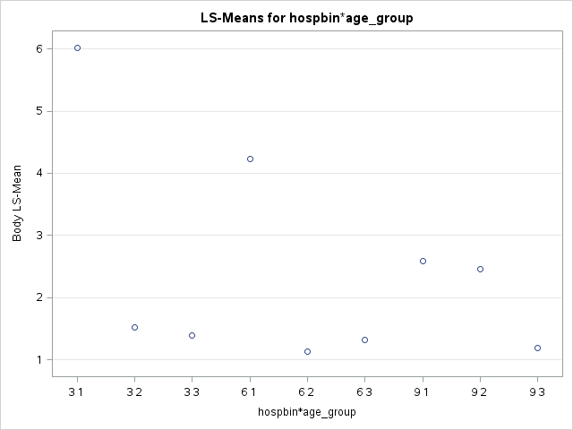

| hospbin | age_group | Tail LSMEAN |
| --- | --- | --- |
| 3 | 1 | 6.90823000 |
| 3 | 2 | 1.92138000 |
| 3 | 3 | 1.79991000 |
| 6 | 1 | 5.24763333 |
| 6 | 2 | 2.33609867 |
| 6 | 3 | 1.98929095 |
| 9 | 1 | 3.28853000 |
| 9 | 2 | 2.82407667 |
| 9 | 3 | 1.97769104 |

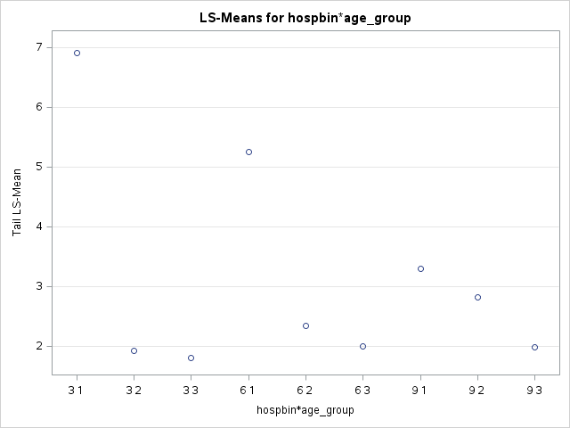

The Mixed Procedure

| Model Information |  |
| --- | --- |
| Data Set | WORK.INSULIN |
| Dependent Variable | percent_insulin |
| Covariance Structure | Unstructured |
| Subject Effect | Case(hospbin) |
| Estimation Method | REML |
| Residual Variance Method | None |
| Fixed Effects SE Method | Model-Based |
| Degrees of Freedom Method | Between-Within |

| Class Level Information Class | Class Level Information Levels | Class Level Information Values |
| --- | --- | --- |
| Case | 39 | 6003 6005 6007 6008 6011 6019 6047 6048 6057 6060 6073 6099 6104 6106 6115 6117 6126 6129 6131 6134 6140 6144 6162 6165 6172 6174 6178 6179 6187 6200 6219 6229 6230 6235 6250 6251 6254 6278 6279 |
| hospbin | 3 | 3 6 9 |
| age_group | 3 | 1 2 3 |
| sample_type2 | 3 | A B C |

| Dimensions |  |
| --- | --- |
| Covariance Parameters | 6 |
| Columns in X | 64 |
| Columns in Z | 0 |
| Subjects | 39 |
| Max Obs per Subject | 3 |

| Number of Observations |  |
| --- | --- |
| Number of Observations Read | 117 |
| Number of Observations Used | 117 |
| Number of Observations Not Used | 0 |

| Iteration History Iteration | Iteration History Evaluations | Iteration History -2 Res Log Like | Iteration History Criterion |
| --- | --- | --- | --- |
| 0 | 1 | 439.24643330 |  |
| 1 | 1 | 303.07256043 | 0.00000000 |

| Convergence criteria met. |
| --- |

| Covariance Parameter Estimates Cov Parm | Covariance Parameter Estimates Subject | Covariance Parameter Estimates Estimate |
| --- | --- | --- |
| UN(1,1) | Case(hospbin) | 6.7337 |
| UN(2,1) | Case(hospbin) | 4.9685 |
| UN(2,2) | Case(hospbin) | 4.0626 |
| UN(3,1) | Case(hospbin) | 5.1353 |
| UN(3,2) | Case(hospbin) | 4.2510 |
| UN(3,3) | Case(hospbin) | 5.0433 |

| Fit Statistics |  |
| --- | --- |
| -2 Res Log Likelihood | 303.1 |
| AIC (Smaller is Better) | 315.1 |
| AICC (Smaller is Better) | 316.1 |
| BIC (Smaller is Better) | 325.1 |

| Null Model Likelihood Ratio Test DF | Null Model Likelihood Ratio Test Chi-Square | Null Model Likelihood Ratio Test Pr > ChiSq |
| --- | --- | --- |
| 5 | 136.17 | <.0001 |

| Type 3 Tests of Fixed Effects Effect | Type 3 Tests of Fixed Effects Num DF | Type 3 Tests of Fixed Effects Den DF | Type 3 Tests of Fixed Effects F Value | Type 3 Tests of Fixed Effects Pr > F |
| --- | --- | --- | --- | --- |
| hospbin | 2 | 30 | 0.49 | 0.6193 |
| age_group | 2 | 30 | 8.81 | 0.0010 |
| hospbin*age_group | 4 | 30 | 1.18 | 0.3386 |
| sample_type2 | 2 | 30 | 13.64 | <.0001 |
| hospbin*sample_type2 | 4 | 30 | 0.67 | 0.6151 |
| age_group*sample_typ | 4 | 30 | 2.73 | 0.0478 |
| hospbi*age_gr*sample | 8 | 30 | 1.07 | 0.4101 |

| Least Squares Means Effect | Least Squares Means sample_type2 | Least Squares Means hospbin | Least Squares Means age_group | Least Squares Means Estimate | Least Squares Means Standard Error | Least Squares Means DF | Least Squares Means t Value | Least Squares Means Pr > \|t\| | Least Squares Means Alpha | Least Squares Means Lower | Least Squares Means Upper |
| --- | --- | --- | --- | --- | --- | --- | --- | --- | --- | --- | --- |
| hospbin |  | 3 |  | 3.3974 | 0.7260 | 30 | 4.68 | <.0001 | 0.05 | 1.9148 | 4.8801 |
| hospbin |  | 6 |  | 2.6716 | 0.7008 | 30 | 3.81 | 0.0006 | 0.05 | 1.2405 | 4.1028 |
| hospbin |  | 9 |  | 2.3427 | 0.8696 | 30 | 2.69 | 0.0115 | 0.05 | 0.5667 | 4.1187 |
| age_group |  |  | 1 | 4.9068 | 0.6770 | 30 | 7.25 | <.0001 | 0.05 | 3.5242 | 6.2894 |
| age_group |  |  | 2 | 2.0216 | 1.0488 | 30 | 1.93 | 0.0634 | 0.05 | -0.1204 | 4.1635 |
| age_group |  |  | 3 | 1.4834 | 0.4648 | 30 | 3.19 | 0.0033 | 0.05 | 0.5341 | 2.4327 |
| hospbin*age_group |  | 3 | 1 | 7.0260 | 1.2845 | 30 | 5.47 | <.0001 | 0.05 | 4.4026 | 9.6493 |
| hospbin*age_group |  | 3 | 2 | 1.6716 | 1.5732 | 30 | 1.06 | 0.2965 | 0.05 | -1.5413 | 4.8845 |
| hospbin*age_group |  | 3 | 3 | 1.4948 | 0.7866 | 30 | 1.90 | 0.0670 | 0.05 | -0.1117 | 3.1013 |
| hospbin*age_group |  | 6 | 1 | 4.8118 | 1.1124 | 30 | 4.33 | 0.0002 | 0.05 | 2.5399 | 7.0836 |
| hospbin*age_group |  | 6 | 2 | 1.7096 | 1.5732 | 30 | 1.09 | 0.2858 | 0.05 | -1.5033 | 4.9225 |
| hospbin*age_group |  | 6 | 3 | 1.4934 | 0.8409 | 30 | 1.78 | 0.0859 | 0.05 | -0.2239 | 3.2108 |
| hospbin*age_group |  | 9 | 1 | 2.8827 | 1.1124 | 30 | 2.59 | 0.0146 | 0.05 | 0.6108 | 5.1545 |
| hospbin*age_group |  | 9 | 2 | 2.6836 | 2.2248 | 30 | 1.21 | 0.2372 | 0.05 | -1.8602 | 7.2273 |
| hospbin*age_group |  | 9 | 3 | 1.4619 | 0.7866 | 30 | 1.86 | 0.0729 | 0.05 | -0.1446 | 3.0683 |
| sample_type2 | A |  |  | 2.8435 | 0.5179 | 30 | 5.49 | <.0001 | 0.05 | 1.7858 | 3.9011 |
| sample_type2 | B |  |  | 2.4246 | 0.4023 | 30 | 6.03 | <.0001 | 0.05 | 1.6031 | 3.2461 |
| sample_type2 | C |  |  | 3.1436 | 0.4482 | 30 | 7.01 | <.0001 | 0.05 | 2.2283 | 4.0590 |
| hospbin*sample_type2 | A | 3 |  | 3.6761 | 0.8468 | 30 | 4.34 | 0.0001 | 0.05 | 1.9467 | 5.4054 |
| hospbin*sample_type2 | B | 3 |  | 2.9731 | 0.6577 | 30 | 4.52 | <.0001 | 0.05 | 1.6299 | 4.3163 |
| hospbin*sample_type2 | C | 3 |  | 3.5432 | 0.7328 | 30 | 4.84 | <.0001 | 0.05 | 2.0466 | 5.0398 |
| hospbin*sample_type2 | A | 6 |  | 2.5954 | 0.8173 | 30 | 3.18 | 0.0034 | 0.05 | 0.9262 | 4.2646 |
| hospbin*sample_type2 | B | 6 |  | 2.2284 | 0.6348 | 30 | 3.51 | 0.0014 | 0.05 | 0.9319 | 3.5250 |
| hospbin*sample_type2 | C | 6 |  | 3.1910 | 0.7073 | 30 | 4.51 | <.0001 | 0.05 | 1.7464 | 4.6356 |
| hospbin*sample_type2 | A | 9 |  | 2.2590 | 1.0143 | 30 | 2.23 | 0.0336 | 0.05 | 0.1876 | 4.3304 |
| hospbin*sample_type2 | B | 9 |  | 2.0723 | 0.7878 | 30 | 2.63 | 0.0133 | 0.05 | 0.4634 | 3.6813 |
| hospbin*sample_type2 | C | 9 |  | 2.6968 | 0.8778 | 30 | 3.07 | 0.0045 | 0.05 | 0.9041 | 4.4894 |
| age_group*sample_typ | A |  | 1 | 5.2953 | 0.7896 | 30 | 6.71 | <.0001 | 0.05 | 3.6827 | 6.9079 |
| age_group*sample_typ | B |  | 1 | 4.2770 | 0.6133 | 30 | 6.97 | <.0001 | 0.05 | 3.0244 | 5.5296 |
| age_group*sample_typ | C |  | 1 | 5.1481 | 0.6834 | 30 | 7.53 | <.0001 | 0.05 | 3.7525 | 6.5437 |
| age_group*sample_typ | A |  | 2 | 2.0029 | 1.2233 | 30 | 1.64 | 0.1120 | 0.05 | -0.4954 | 4.5011 |
| age_group*sample_typ | B |  | 2 | 1.7014 | 0.9502 | 30 | 1.79 | 0.0835 | 0.05 | -0.2391 | 3.6418 |
| age_group*sample_typ | C |  | 2 | 2.3605 | 1.0586 | 30 | 2.23 | 0.0334 | 0.05 | 0.1985 | 4.5226 |
| age_group*sample_typ | A |  | 3 | 1.2323 | 0.5422 | 30 | 2.27 | 0.0304 | 0.05 | 0.1251 | 2.3395 |
| age_group*sample_typ | B |  | 3 | 1.2955 | 0.4211 | 30 | 3.08 | 0.0044 | 0.05 | 0.4355 | 2.1555 |
| age_group*sample_typ | C |  | 3 | 1.9223 | 0.4692 | 30 | 4.10 | 0.0003 | 0.05 | 0.9641 | 2.8805 |
| hospbi*age_gr*sample | A | 3 | 1 | 8.1524 | 1.4982 | 30 | 5.44 | <.0001 | 0.05 | 5.0927 | 11.2121 |
| hospbi*age_gr*sample | B | 3 | 1 | 6.0173 | 1.1637 | 30 | 5.17 | <.0001 | 0.05 | 3.6407 | 8.3939 |
| hospbi*age_gr*sample | C | 3 | 1 | 6.9082 | 1.2966 | 30 | 5.33 | <.0001 | 0.05 | 4.2603 | 9.5562 |
| hospbi*age_gr*sample | A | 3 | 2 | 1.5775 | 1.8349 | 30 | 0.86 | 0.3968 | 0.05 | -2.1699 | 5.3248 |
| hospbi*age_gr*sample | B | 3 | 2 | 1.5158 | 1.4252 | 30 | 1.06 | 0.2960 | 0.05 | -1.3949 | 4.4266 |
| hospbi*age_gr*sample | C | 3 | 2 | 1.9214 | 1.5880 | 30 | 1.21 | 0.2357 | 0.05 | -1.3217 | 5.1644 |
| hospbi*age_gr*sample | A | 3 | 3 | 1.2983 | 0.9174 | 30 | 1.42 | 0.1673 | 0.05 | -0.5753 | 3.1720 |
| hospbi*age_gr*sample | B | 3 | 3 | 1.3862 | 0.7126 | 30 | 1.95 | 0.0612 | 0.05 | -0.06919 | 2.8415 |
| hospbi*age_gr*sample | C | 3 | 3 | 1.7999 | 0.7940 | 30 | 2.27 | 0.0308 | 0.05 | 0.1784 | 3.4214 |
| hospbi*age_gr*sample | A | 6 | 1 | 4.9560 | 1.2975 | 30 | 3.82 | 0.0006 | 0.05 | 2.3063 | 7.6058 |
| hospbi*age_gr*sample | B | 6 | 1 | 4.2316 | 1.0078 | 30 | 4.20 | 0.0002 | 0.05 | 2.1734 | 6.2898 |
| hospbi*age_gr*sample | C | 6 | 1 | 5.2476 | 1.1229 | 30 | 4.67 | <.0001 | 0.05 | 2.9544 | 7.5408 |
| hospbi*age_gr*sample | A | 6 | 2 | 1.6554 | 1.8349 | 30 | 0.90 | 0.3741 | 0.05 | -2.0919 | 5.4028 |
| hospbi*age_gr*sample | B | 6 | 2 | 1.1374 | 1.4252 | 30 | 0.80 | 0.4311 | 0.05 | -1.7734 | 4.0481 |
| hospbi*age_gr*sample | C | 6 | 2 | 2.3361 | 1.5880 | 30 | 1.47 | 0.1517 | 0.05 | -0.9070 | 5.5792 |
| hospbi*age_gr*sample | A | 6 | 3 | 1.1747 | 0.9808 | 30 | 1.20 | 0.2404 | 0.05 | -0.8284 | 3.1777 |
| hospbi*age_gr*sample | B | 6 | 3 | 1.3163 | 0.7618 | 30 | 1.73 | 0.0943 | 0.05 | -0.2395 | 2.8722 |
| hospbi*age_gr*sample | C | 6 | 3 | 1.9893 | 0.8488 | 30 | 2.34 | 0.0259 | 0.05 | 0.2558 | 3.7228 |
| hospbi*age_gr*sample | A | 9 | 1 | 2.7774 | 1.2975 | 30 | 2.14 | 0.0406 | 0.05 | 0.1276 | 5.4272 |
| hospbi*age_gr*sample | B | 9 | 1 | 2.5821 | 1.0078 | 30 | 2.56 | 0.0157 | 0.05 | 0.5239 | 4.6402 |
| hospbi*age_gr*sample | C | 9 | 1 | 3.2885 | 1.1229 | 30 | 2.93 | 0.0064 | 0.05 | 0.9953 | 5.5817 |
| hospbi*age_gr*sample | A | 9 | 2 | 2.7757 | 2.5949 | 30 | 1.07 | 0.2933 | 0.05 | -2.5238 | 8.0753 |
| hospbi*age_gr*sample | B | 9 | 2 | 2.4509 | 2.0156 | 30 | 1.22 | 0.2335 | 0.05 | -1.6655 | 6.5672 |
| hospbi*age_gr*sample | C | 9 | 2 | 2.8241 | 2.2457 | 30 | 1.26 | 0.2183 | 0.05 | -1.7623 | 7.4105 |
| hospbi*age_gr*sample | A | 9 | 3 | 1.2239 | 0.9174 | 30 | 1.33 | 0.1922 | 0.05 | -0.6498 | 3.0976 |
| hospbi*age_gr*sample | B | 9 | 3 | 1.1840 | 0.7126 | 30 | 1.66 | 0.1070 | 0.05 | -0.2713 | 2.6394 |
| hospbi*age_gr*sample | C | 9 | 3 | 1.9777 | 0.7940 | 30 | 2.49 | 0.0185 | 0.05 | 0.3562 | 3.5992 |

| Differences of Least Squares Means Effect | Differences of Least Squares Means sample_type2 | Differences of Least Squares Means hospbin | Differences of Least Squares Means age_group | Differences of Least Squares Means _sample_type2 | Differences of Least Squares Means hospbin | Differences of Least Squares Means _age_group | Differences of Least Squares Means Estimate | Differences of Least Squares Means Standard Error | Differences of Least Squares Means DF | Differences of Least Squares Means t Value | Differences of Least Squares Means Pr > \|t\| | Differences of Least Squares Means Adjustment | Differences of Least Squares Means Adj P | Differences of Least Squares Means Alpha | Differences of Least Squares Means Lower | Differences of Least Squares Means Upper | Differences of Least Squares Means Adj Lower | Differences of Least Squares Means Adj Upper |
| --- | --- | --- | --- | --- | --- | --- | --- | --- | --- | --- | --- | --- | --- | --- | --- | --- | --- | --- |
| hospbin |  | 3 |  |  | 6 |  | 0.7258 | 1.0090 | 30 | 0.72 | 0.4775 | Tukey-Kramer | 0.7541 | 0.05 | -1.3349 | 2.7865 | -1.7617 | 3.2133 |
| hospbin |  | 3 |  |  | 9 |  | 1.0547 | 1.1328 | 30 | 0.93 | 0.3593 | Tukey-Kramer | 0.6252 | 0.05 | -1.2588 | 3.3683 | -1.7380 | 3.8475 |
| hospbin |  | 6 |  |  | 9 |  | 0.3289 | 1.1168 | 30 | 0.29 | 0.7704 | Tukey-Kramer | 0.9534 | 0.05 | -1.9520 | 2.6098 | -2.4244 | 3.0822 |
| age_group |  |  | 1 |  |  | 2 | 2.8852 | 1.2483 | 30 | 2.31 | 0.0279 | Tukey-Kramer | 0.0695 | 0.05 | 0.3358 | 5.4346 | -0.1922 | 5.9626 |
| age_group |  |  | 1 |  |  | 3 | 3.4234 | 0.8212 | 30 | 4.17 | 0.0002 | Tukey-Kramer | 0.0007 | 0.05 | 1.7463 | 5.1006 | 1.3989 | 5.4479 |
| age_group |  |  | 2 |  |  | 3 | 0.5382 | 1.1472 | 30 | 0.47 | 0.6424 | Tukey-Kramer | 0.8862 | 0.05 | -1.8047 | 2.8811 | -2.2899 | 3.3663 |
| hospbin*age_group |  | 3 | 1 |  | 3 | 2 | 5.3544 | 2.0310 | 30 | 2.64 | 0.0131 | Tukey-Kramer | 0.2140 | 0.05 | 1.2066 | 9.5022 | -1.4240 | 12.1328 |
| hospbin*age_group |  | 3 | 1 |  | 3 | 3 | 5.5312 | 1.5062 | 30 | 3.67 | 0.0009 | Tukey-Kramer | 0.0226 | 0.05 | 2.4550 | 8.6073 | 0.5041 | 10.5582 |
| hospbin*age_group |  | 3 | 1 |  | 6 | 1 | 2.2142 | 1.6993 | 30 | 1.30 | 0.2025 | Tukey-Kramer | 0.9226 | 0.05 | -1.2561 | 5.6845 | -3.4571 | 7.8855 |
| hospbin*age_group |  | 3 | 1 |  | 6 | 2 | 5.3163 | 2.0310 | 30 | 2.62 | 0.0137 | Tukey-Kramer | 0.2213 | 0.05 | 1.1685 | 9.4642 | -1.4621 | 12.0948 |
| hospbin*age_group |  | 3 | 1 |  | 6 | 3 | 5.5325 | 1.5353 | 30 | 3.60 | 0.0011 | Tukey-Kramer | 0.0267 | 0.05 | 2.3971 | 8.6680 | 0.4085 | 10.6566 |
| hospbin*age_group |  | 3 | 1 |  | 9 | 1 | 4.1433 | 1.6993 | 30 | 2.44 | 0.0209 | Tukey-Kramer | 0.3009 | 0.05 | 0.6730 | 7.6136 | -1.5279 | 9.8146 |
| hospbin*age_group |  | 3 | 1 |  | 9 | 2 | 4.3424 | 2.5690 | 30 | 1.69 | 0.1013 | Tukey-Kramer | 0.7474 | 0.05 | -0.9042 | 9.5891 | -4.2317 | 12.9165 |
| hospbin*age_group |  | 3 | 1 |  | 9 | 3 | 5.5641 | 1.5062 | 30 | 3.69 | 0.0009 | Tukey-Kramer | 0.0214 | 0.05 | 2.4880 | 8.6402 | 0.5371 | 10.5911 |
| hospbin*age_group |  | 3 | 2 |  | 3 | 3 | 0.1768 | 1.7589 | 30 | 0.10 | 0.9206 | Tukey-Kramer | 1.0000 | 0.05 | -3.4154 | 3.7689 | -5.6935 | 6.0471 |
| hospbin*age_group |  | 3 | 2 |  | 6 | 1 | -3.1402 | 1.9268 | 30 | -1.63 | 0.1136 | Tukey-Kramer | 0.7814 | 0.05 | -7.0752 | 0.7948 | -9.5708 | 3.2904 |
| hospbin*age_group |  | 3 | 2 |  | 6 | 2 | -0.03807 | 2.2248 | 30 | -0.02 | 0.9865 | Tukey-Kramer | 1.0000 | 0.05 | -4.5818 | 4.5057 | -7.4635 | 7.3873 |
| hospbin*age_group |  | 3 | 2 |  | 6 | 3 | 0.1781 | 1.7838 | 30 | 0.10 | 0.9211 | Tukey-Kramer | 1.0000 | 0.05 | -3.4650 | 3.8212 | -5.7754 | 6.1317 |
| hospbin*age_group |  | 3 | 2 |  | 9 | 1 | -1.2111 | 1.9268 | 30 | -0.63 | 0.5344 | Tukey-Kramer | 0.9993 | 0.05 | -5.1461 | 2.7239 | -7.6417 | 5.2195 |
| hospbin*age_group |  | 3 | 2 |  | 9 | 2 | -1.0120 | 2.7249 | 30 | -0.37 | 0.7130 | Tukey-Kramer | 1.0000 | 0.05 | -6.5769 | 4.5529 | -10.1062 | 8.0822 |
| hospbin*age_group |  | 3 | 2 |  | 9 | 3 | 0.2097 | 1.7589 | 30 | 0.12 | 0.9059 | Tukey-Kramer | 1.0000 | 0.05 | -3.3825 | 3.8018 | -5.6606 | 6.0800 |
| hospbin*age_group |  | 3 | 3 |  | 6 | 1 | -3.3170 | 1.3624 | 30 | -2.43 | 0.0211 | Tukey-Kramer | 0.3027 | 0.05 | -6.0994 | -0.5345 | -7.8641 | 1.2301 |
| hospbin*age_group |  | 3 | 3 |  | 6 | 2 | -0.2148 | 1.7589 | 30 | -0.12 | 0.9036 | Tukey-Kramer | 1.0000 | 0.05 | -3.8070 | 3.3773 | -6.0851 | 5.6555 |
| hospbin*age_group |  | 3 | 3 |  | 6 | 3 | 0.001368 | 1.1515 | 30 | 0.00 | 0.9991 | Tukey-Kramer | 1.0000 | 0.05 | -2.3502 | 2.3530 | -3.8416 | 3.8444 |
| hospbin*age_group |  | 3 | 3 |  | 9 | 1 | -1.3879 | 1.3624 | 30 | -1.02 | 0.3165 | Tukey-Kramer | 0.9809 | 0.05 | -4.1703 | 1.3946 | -5.9350 | 3.1593 |
| hospbin*age_group |  | 3 | 3 |  | 9 | 2 | -1.1888 | 2.3598 | 30 | -0.50 | 0.6181 | Tukey-Kramer | 0.9999 | 0.05 | -6.0081 | 3.6306 | -9.0646 | 6.6871 |
| hospbin*age_group |  | 3 | 3 |  | 9 | 3 | 0.03292 | 1.1124 | 30 | 0.03 | 0.9766 | Tukey-Kramer | 1.0000 | 0.05 | -2.2389 | 2.3048 | -3.6798 | 3.7456 |
| hospbin*age_group |  | 6 | 1 |  | 6 | 2 | 3.1021 | 1.9268 | 30 | 1.61 | 0.1179 | Tukey-Kramer | 0.7920 | 0.05 | -0.8329 | 7.0371 | -3.3285 | 9.5327 |
| hospbin*age_group |  | 6 | 1 |  | 6 | 3 | 3.3183 | 1.3945 | 30 | 2.38 | 0.0239 | Tukey-Kramer | 0.3305 | 0.05 | 0.4704 | 6.1663 | -1.3358 | 7.9725 |
| hospbin*age_group |  | 6 | 1 |  | 9 | 1 | 1.9291 | 1.5732 | 30 | 1.23 | 0.2297 | Tukey-Kramer | 0.9440 | 0.05 | -1.2838 | 5.1420 | -3.3215 | 7.1797 |

[output cut: 438 more lines]

```sas
PROC glm data=insulin1;
     class hospbin age_group;
     model Head Body Tail= hospbin|age_group/nouni;
     repeated sample_type2 / short printe;
     lsmeans hospbin|age_group / out=insulin1_means (drop=stderr);
run;
quit;

PROC mixed data=insulin;
     class case hospbin age_group sample_type2;
     model percent_insulin=hospbin|age_group|sample_type2;
     repeated sample_type2/ subject=case(hospbin) type=un;
     lsmeans hospbin|age_group|sample_type2 /adjust=tukey cl pdiff alpha=0.05;
run;
```

Data for supplemental table 2 and Figure 1

```sas
/*ls means values by head body and tail*/

DATA insulin1_lsmeans1 (drop=age_group);
     set insulin1_means;
     if age_group^="" then delete;
     stain="Insulin           ";
     rename _NAME_=pancreas_region;
run;

PROC print data=insulin1_lsmeans1;
run;

/*grand mean values*/

PROC means data=insulin1_lsmeans1 mean;
     var lsmean;
     class hospbin;
     output out=insulin1_grandmean;
run;

DATA insulin1_grandmean (drop=_type_ _freq_ _stat_);
     set insulin1_grandmean;
     if _stat_^="MEAN" then delete;
     if hospbin="" then delete;
     pancreas_region="Overall";
     stain="Insulin           ";
run;

/*combine files into 1*/

DATA insulin1_fig1;
     set insulin1_lsmeans1 insulin1_grandmean;
run;

PROC print data=insulin1_fig1;
run;
```

| Obs | pancreas_region | hospbin | LSMEAN | stain |
| --- | --- | --- | --- | --- |
| 1 | Head | 3 | 3.67605 | Insulin |
| 2 | Head | 6 | 2.59539 | Insulin |
| 3 | Head | 9 | 2.25901 | Insulin |
| 4 | Body | 3 | 2.97310 | Insulin |
| 5 | Body | 6 | 2.22844 | Insulin |
| 6 | Body | 9 | 2.07233 | Insulin |
| 7 | Tail | 3 | 3.54317 | Insulin |
| 8 | Tail | 6 | 3.19101 | Insulin |
| 9 | Tail | 9 | 2.69677 | Insulin |

The MEANS Procedure

| Analysis Variable : LSMEAN hospbin | Analysis Variable : LSMEAN N Obs | Analysis Variable : LSMEAN Mean |
| --- | --- | --- |
| 3 | 3 | 3.3974434 |
| 6 | 3 | 2.6716118 |
| 9 | 3 | 2.3427013 |

| Obs | pancreas_region | hospbin | LSMEAN | stain |
| --- | --- | --- | --- | --- |
| 1 | Head | 3 | 3.67605 | Insulin |
| 2 | Head | 6 | 2.59539 | Insulin |
| 3 | Head | 9 | 2.25901 | Insulin |
| 4 | Body | 3 | 2.97310 | Insulin |
| 5 | Body | 6 | 2.22844 | Insulin |
| 6 | Body | 9 | 2.07233 | Insulin |
| 7 | Tail | 3 | 3.54317 | Insulin |
| 8 | Tail | 6 | 3.19101 | Insulin |
| 9 | Tail | 9 | 2.69677 | Insulin |
| 10 | Overall | 3 | 3.39744 | Insulin |
| 11 | Overall | 6 | 2.67161 | Insulin |
| 12 | Overall | 9 | 2.34270 | Insulin |

### Ki67 alone dataset

statistical analysis model